# Pertemuan 1

```r
library("forecast")
```

```r
library("graphics")
library("TTR")
library("TSA")
library(rio)
dt <- import("https://raw.githubusercontent.com/audrynakhairunnisa/mpdw/main/Pertemuan%201/Air%20Quality%20Historical%20%28Data%20Individu%29.xlsx")

# menampilkan 5 data pertama
head(dt)
```

```
##   t    Tanggal PM2.5 (ug/m3)
## 1 1 2025-04-13       55.3458
## 2 2 2025-04-14       38.0958
## 3 3 2025-04-15       66.4750
## 4 4 2025-04-16       71.3542
## 5 5 2025-04-17       85.8792
## 6 6 2025-04-18       78.6708
```

## Eksplorasi Data

`View()` : menampilkan data dalam bentuk tabel, `str()` : menampilkan struktur data, `dim()` : menampilkan dimensi data

```r
View(dt)
str(dt)
```

```
## 'data.frame':    156 obs. of  3 variables:
##  $ t            : num  1 2 3 4 5 6 7 8 9 10 ...
##  $ Tanggal      : chr  "2025-04-13" "2025-04-14" "2025-04-15" "2025-04-16" ...
##  $ PM2.5 (ug/m3): num  55.3 38.1 66.5 71.4 85.9 ...
```

```r
dim(dt)
```

```
## [1] 156   3
```

Mengubah data agar terbaca sebagai data deret waktu dengan fungsi `ts()` .

```r
dt.ts <- ts(dt$`PM2.5 (ug/m3)`)
```

Menampilkan ringkasan data

```r
summary(dt.ts)
```

```
##    Min. 1st Qu.  Median    Mean 3rd Qu.    Max.
##   32.33   70.46   85.84   84.68   99.51  150.09
```

Membuat plot data deret waktu

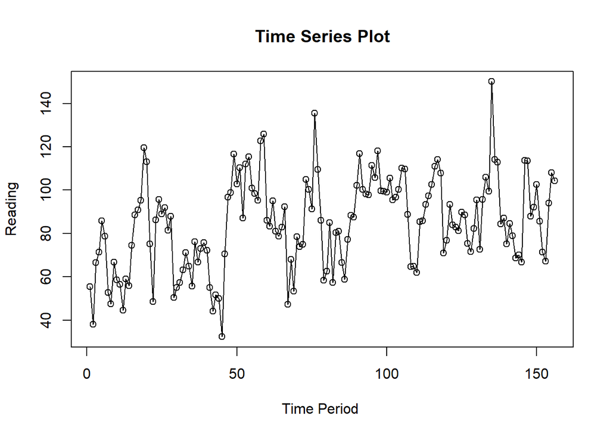

```r
ts.plot(dt.ts, xlab="Time Period ", ylab="Reading",
        main = "Time Series Plot")
points(dt.ts)
```

```r
#menyimpan plot
dev.copy(png, "plot_dt.png")
```

```r
dev.off()
```

## Single Moving Average & Double Moving Average

### Pembagian Data

Pembagian data latih dan data uji dilakukan dengan perbandingan 80% data latih dan 20% data uji.

```r
# hitung jumlah data
n <- nrow(dt)

# tentukan batas 80%
n_train <- floor(0.8 * n)

# bagi data
training_ma <- dt[1:n_train, ]
testing_ma  <- dt[(n_train+1):n, ]

# ubah ke time series
train_ma.ts <- ts(training_ma$`PM2.5 (ug/m3)`)
test_ma.ts  <- ts(testing_ma$`PM2.5 (ug/m3)`)
```

Eksplorasi data dilakukan pada keseluruhan data, data latih serta data uji menggunakan plot data deret waktu.

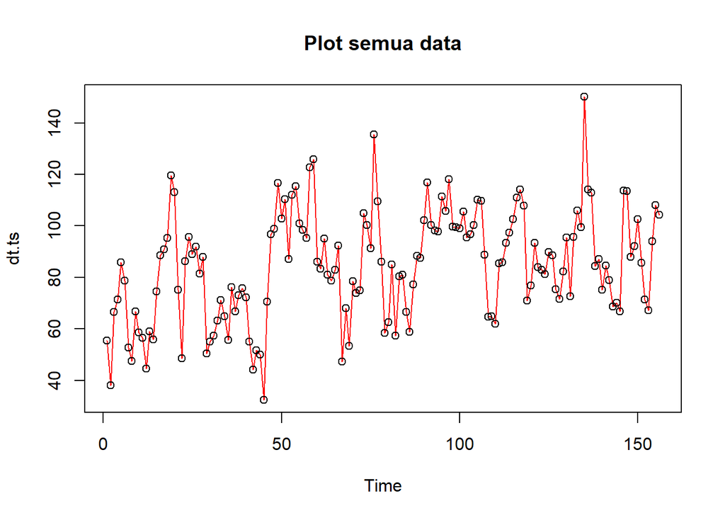

```r
#eksplorasi keseluruhan data
plot(dt.ts, col="red",main="Plot semua data")
points(dt.ts)
```

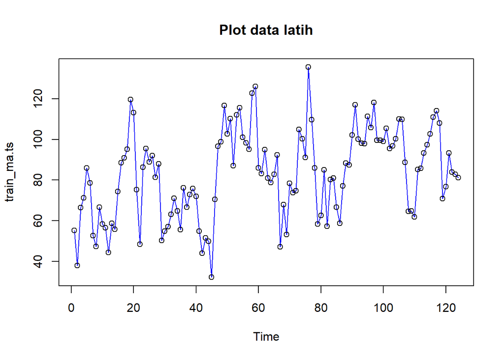

```r
#eksplorasi data latih
plot(train_ma.ts, col="blue",main="Plot data latih")
points(train_ma.ts)
```

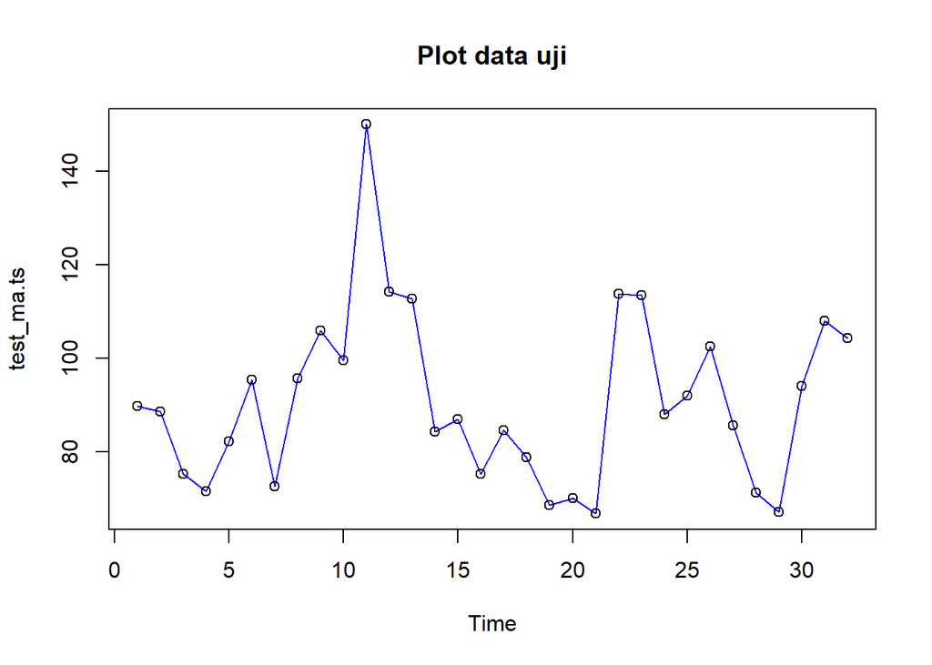

```r
#eksplorasi data uji
plot(test_ma.ts, col="blue",main="Plot data uji")
points(test_ma.ts)
```

Eksplorasi data juga dapat dilakukan menggunakan package `ggplot2` dengan terlebih dahulu memanggil library *package* `ggplot2`.

```r
dt$Tanggal <- as.Date(dt$Tanggal)
```

```
## `geom_line()`: Each group consists of only one observation.
## ℹ Do you need to adjust the group aesthetic?
## `geom_line()`: Each group consists of only one observation.
## ℹ Do you need to adjust the group aesthetic?
```

[figure not shown]

```r
library(ggplot2)
ggplot() +
  geom_line(
    data = training_ma,
    aes(x = Tanggal, y = `PM2.5 (ug/m3)`, col = "Data Latih")
  ) +
  geom_line(
    data = testing_ma,
    aes(x = Tanggal, y = `PM2.5 (ug/m3)`, col = "Data Uji")
  ) +
  labs(
    x = "Periode Waktu",
    y = "PM2.5 (ug/m3)",
    color = "Legend"
  ) +
  scale_colour_manual(
    name = "Keterangan:",
    breaks = c("Data Latih", "Data Uji"),
    values = c("blue", "red")
  ) +
  theme_bw() +
  theme(
    legend.position = "bottom",
    plot.caption = element_text(hjust = 0.5, size = 12)
  )
```

### Single Moving Average (SMA)

Ide dasar dari Single Moving Average (SMA) adalah data suatu periode dipengaruhi oleh data periode sebelumnya. Metode pemulusan ini cocok digunakan untuk pola data stasioner atau konstan. Prinsip dasar metode pemulusan ini adalah data pemulusan pada periode ke-t merupakan rata rata dari m buah data pada periode ke-t hingga periode ke (t-m+1).

$$S_t = \frac{1}{m} \sum_{i=t-m+1}^{t} X_i$$

Data pemulusan pada periode ke-t selanjutnya digunakan sebagai nilai peramalan pada periode ke t+1.

$$F_t = S_{t-1}, F_{n,h} = S_n$$

Pemulusan menggunakan metode SMA dilakukan dengan fungsi `SMA()`. Dalam hal ini akan dilakukan pemulusan dengan parameter `m=4`.

```r
data.sma<-SMA(train_ma.ts, n=4)
data.sma
```

```
## Time Series:
## Start = 1
## End = 124
## Frequency = 1
##   [1]        NA        NA        NA  57.81770  65.45105  75.59480  72.17500
##   [8]  66.19687  61.38957  56.34895  57.29062  56.57082  54.63020  53.96770
##  [15]  58.44165  69.45102  77.44790  87.27602  98.56562 104.70730 100.79687
##  [22]  89.15000  80.82602  76.43122  79.85310  90.70727  89.48020  87.58540
##  [29]  77.93750  68.67395  62.62290  56.42290  61.63540  64.10207  63.72500
##  [36]  66.97710  65.84480  67.88542  72.92085  71.89167  68.96875  61.75520
##  [43]  55.70622  50.15517  44.49685  51.11457  62.37500  74.61875  95.68230
##  [50] 103.71562 107.11145 104.13957 102.99270 106.17602 103.86250 106.69792
##  [57] 102.49480 104.29272 110.52605 107.42918 104.44375  97.51875  86.26563
##  [64]  84.46458  84.37813  83.74583  75.31978  72.61563  65.21250  61.72293
##  [71]  68.38753  70.11460  83.00000  88.47293  92.79375 107.95208 109.13855
##  [78] 105.55832  97.35520  79.14375  73.01562  65.82398  71.30210  75.90940
##  [85]  71.30418  71.67500  70.89793  72.71355  77.92605  88.76355  98.70938
##  [92] 101.67915 104.34895 103.27707 101.86457 103.25207 108.21665 108.67290
##  [99] 105.72083 104.05730 100.91043  99.86773  99.18648  99.50418 100.66252
## [106] 104.24585 102.22187  93.28855  81.99375  70.00207  69.16042  74.45417
## [113]  81.55312  90.41980  94.74270 101.02810 106.23852 108.89477 100.96562
## [120]  92.41667  87.21042  81.21250  84.21875  85.33230
```

Data pemulusan pada periode ke-t selanjutnya digunakan sebagai nilai peramalan pada periode ke t+1 sehingga hasil peramalan 1 periode kedepan adalah sebagai berikut.

```r
data.ramal<-c(NA,data.sma)
data.ramal #forecast 1 periode ke depan
```

```
##   [1]        NA        NA        NA        NA  57.81770  65.45105  75.59480
##   [8]  72.17500  66.19687  61.38957  56.34895  57.29062  56.57082  54.63020
##  [15]  53.96770  58.44165  69.45102  77.44790  87.27602  98.56562 104.70730
##  [22] 100.79687  89.15000  80.82602  76.43122  79.85310  90.70727  89.48020
##  [29]  87.58540  77.93750  68.67395  62.62290  56.42290  61.63540  64.10207
##  [36]  63.72500  66.97710  65.84480  67.88542  72.92085  71.89167  68.96875
##  [43]  61.75520  55.70622  50.15517  44.49685  51.11457  62.37500  74.61875
##  [50]  95.68230 103.71562 107.11145 104.13957 102.99270 106.17602 103.86250
##  [57] 106.69792 102.49480 104.29272 110.52605 107.42918 104.44375  97.51875
##  [64]  86.26563  84.46458  84.37813  83.74583  75.31978  72.61563  65.21250
##  [71]  61.72293  68.38753  70.11460  83.00000  88.47293  92.79375 107.95208
##  [78] 109.13855 105.55832  97.35520  79.14375  73.01562  65.82398  71.30210
##  [85]  75.90940  71.30418  71.67500  70.89793  72.71355  77.92605  88.76355
##  [92]  98.70938 101.67915 104.34895 103.27707 101.86457 103.25207 108.21665
##  [99] 108.67290 105.72083 104.05730 100.91043  99.86773  99.18648  99.50418
## [106] 100.66252 104.24585 102.22187  93.28855  81.99375  70.00207  69.16042
## [113]  74.45417  81.55312  90.41980  94.74270 101.02810 106.23852 108.89477
## [120] 100.96562  92.41667  87.21042  81.21250  84.21875  85.33230
```

```r
data.gab<-cbind(
  aktual=c(dt.ts),
  pemulusan=c(data.sma,rep(NA,24)),
  ramalan=c(data.ramal,rep(data.ramal[length(data.ramal)],23)))
data.gab #forecast 24 periode ke depan
```

```
##          aktual pemulusan   ramalan
##   [1,]  55.3458        NA        NA
##   [2,]  38.0958        NA        NA
##   [3,]  66.4750        NA        NA
##   [4,]  71.3542  57.81770        NA
##   [5,]  85.8792  65.45105  57.81770
##   [6,]  78.6708  75.59480  65.45105
##   [7,]  52.7958  72.17500  75.59480
##   [8,]  47.4417  66.19687  72.17500
##   [9,]  66.6500  61.38957  66.19687
##  [10,]  58.5083  56.34895  61.38957
##  [11,]  56.5625  57.29062  56.34895
##  [12,]  44.5625  56.57082  57.29062
##  [13,]  58.8875  54.63020  56.57082
##  [14,]  55.8583  53.96770  54.63020
```

[output cut: 142 more lines]

Adapun plot data deret waktu dari hasil peramalan yang dilakukan adalah sebagai berikut.

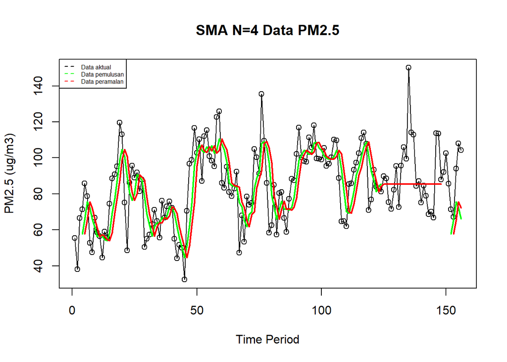

```r
ts.plot(
  dt.ts,
  xlab = "Time Period",
  ylab = "PM2.5 (ug/m3)",
  main = "SMA N=4 Data PM2.5"
)

points(dt.ts)

lines(data.gab[,2], col = "green", lwd = 2)
lines(data.gab[,3], col = "red", lwd = 2)

legend(
  "topleft",
  c("Data aktual", "Data pemulusan", "Data peramalan"),
  lty = 8,
  col = c("black", "green", "red"),
  cex = 0.5
)
```

Selanjutnya perhitungan akurasi dilakukan dengan ukuran akurasi *Sum Squares Error* (SSE), *Mean Square Error* (MSE) dan *Mean Absolute Percentage Error* (MAPE). Perhitungan akurasi dilakukan baik pada data latih maupun pada data uji.

$$SSE = \sum_{t=1}^{n} (y_t - \hat{y}_t)^2$$
$$MSE = \frac{1}{n} \sum_{t=1}^{n} (y_t - \hat{y}_t)^2$$
$$MAPE = \frac{1}{n} \sum_{t=1}^{n} \left|\frac{y_t -
\hat{y}_t}{y_t}\right| * 100$$

```r
#Menghitung nilai keakuratan data latih
error_train.sma = train_ma.ts-data.ramal[1:length(train_ma.ts)]

SSE_train.sma = sum(error_train.sma[5:length(train_ma.ts)]^2)
MSE_train.sma = mean(error_train.sma[5:length(train_ma.ts)]^2)
MAPE_train.sma = mean(abs((error_train.sma[5:length(train_ma.ts)]/train_ma.ts[5:length(train_ma.ts)])*100))

akurasi_train.sma <- matrix(c(SSE_train.sma, MSE_train.sma, MAPE_train.sma))
row.names(akurasi_train.sma)<- c("SSE", "MSE", "MAPE")
colnames(akurasi_train.sma) <- c("Akurasi m = 4")
akurasi_train.sma
```

```
##      Akurasi m = 4
## SSE    42740.30180
## MSE      356.16918
## MAPE      19.64275
```

Dalam hal ini nilai MAPE data latih pada metode pemulusan SMA sekitar 19,64%, nilai ini dapat dikategorikan sebagai nilai akurasi yang baik. Selanjutnya dilakukan perhitungan nilai MAPE data uji pada metode pemulusan SMA.

```r
#Menghitung nilai keakuratan data uji
error_test.sma = test_ma.ts-data.gab[97:120,3]
```

```r
SSE_test.sma = sum(error_test.sma^2)
MSE_test.sma = mean(error_test.sma^2)
MAPE_test.sma = mean(abs((error_test.sma/test_ma.ts*100)))

akurasi_test.sma <- matrix(c(SSE_test.sma, MSE_test.sma, MAPE_test.sma))
row.names(akurasi_test.sma)<- c("SSE", "MSE", "MAPE")
colnames(akurasi_test.sma) <- c("Akurasi m = 4")
akurasi_test.sma
```

```
##      Akurasi m = 4
## SSE    13089.48510
## MSE      409.04641
## MAPE      19.53053
```

### Double Moving Average (DMA)

Metode pemulusan Double Moving Average (DMA) pada dasarnya mirip dengan SMA. Namun demikian, metode ini lebih cocok digunakan untuk pola data trend. Proses pemulusan dengan rata rata dalam metode ini dilakukan sebanyak 2 kali.

- **Tahap I:**

$$S_{1,t} = \frac{1}{m} \sum_{i=t-m+1}^{t} X_i$$

- **Tahap II:**

$$S_{2,t} = \frac{1}{m} \sum_{i=t-m+1}^{t} S_{1,i}$$

Forecast $h$ langkah ke depan dihitung dengan:

$$F_{2,t,t+h} = A_t + B_t \,(h)$$

dengan komponen level ($A_t$) dan tren ($B_t$):

$$A_t = 2S_{1,t} - S_{2,t}
\qquad\text{dan}\qquad
B_t = \frac{2}{m-1}\,\big(S_{1,t} - S_{2,t}\big)$$

```r
dma <- SMA(data.sma, n = 4)
At <- 2*data.sma - dma
Bt <- 2/(4-1)*(data.sma - dma)
data.dma<- At+Bt
data.ramal2<- c(NA, data.dma)

t = 1:24
f = c()

for (i in t) {
  f[i] = At[length(At)] + Bt[length(Bt)]*(i)
}

data.gab2 <- cbind(aktual = c(dt.ts),
                   pemulusan1 = c(data.sma,rep(NA,24)),
                   pemulusan2 = c(dma, rep(NA,24)),
                   At = c(At, rep(NA,24)),
                   Bt = c(Bt,rep(NA,24)),
                   ramalan = c(data.ramal2, f[-1]))
data.gab2
```

```
##          aktual pemulusan1 pemulusan2        At           Bt   ramalan
##   [1,]  55.3458         NA         NA        NA           NA        NA
##   [2,]  38.0958         NA         NA        NA           NA        NA
##   [3,]  66.4750         NA         NA        NA           NA        NA
##   [4,]  71.3542   57.81770         NA        NA           NA        NA
##   [5,]  85.8792   65.45105         NA        NA           NA        NA
##   [6,]  78.6708   75.59480         NA        NA           NA        NA
##   [7,]  52.7958   72.17500   67.75964  76.59036   2.94357500        NA
##   [8,]  47.4417   66.19687   69.85443  62.53932  -2.43837083  79.53394
##   [9,]  66.6500   61.38957   68.83906  53.94009  -4.96632500  60.10095
##  [10,]  58.5083   56.34895   64.02760  48.67030  -5.11910000  48.97376
##  [11,]  56.5625   57.29062   60.30651  54.27474  -2.01058750  43.55120
##  [12,]  44.5625   56.57082   57.89999  55.24166  -0.88611250  52.26416
##  [13,]  58.8875   54.63020   56.21015  53.05025  -1.05330000  54.35554
##  [14,]  55.8583   53.96770   55.61484  52.32056  -1.09809167  51.99695
```

[output cut: 142 more lines]

Hasil pemulusan menggunakan metode DMA divisualisasikan sebagai berikut

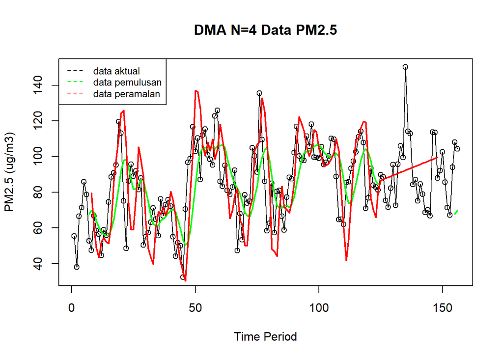

```r
ts.plot(
  dt.ts,
  xlab = "Time Period",
  ylab = "PM2.5 (ug/m3)",
  main = "DMA N=4 Data PM2.5"
)

points(dt.ts)

lines(data.gab2[,3], col="green", lwd=2)
lines(data.gab2[,6], col="red", lwd=2)

legend(
  "topleft",
  c("data aktual", "data pemulusan", "data peramalan"),
  lty=8,
  col=c("black","green","red"),
  cex=0.8
)
```

Selanjutnya perhitungan akurasi dilakukan baik pada data latih maupun data uji. Perhitungan akurasi dilakukan dengan ukuran akurasi SSE, MSE dan MAPE.

```r
#Menghitung nilai keakuratan data latih
error_train.dma = train_ma.ts-data.ramal2[1:length(train_ma.ts)]

SSE_train.dma = sum(error_train.dma[8:length(train_ma.ts)]^2)
MSE_train.dma = mean(error_train.dma[8:length(train_ma.ts)]^2)
MAPE_train.dma = mean(abs((error_train.dma[8:length(train_ma.ts)]/train_ma.ts[8:length(train_ma.ts)])*100))

akurasi_train.dma <- matrix(c(SSE_train.dma, MSE_train.dma, MAPE_train.dma))
row.names(akurasi_train.dma)<- c("SSE", "MSE", "MAPE")
colnames(akurasi_train.dma) <- c("Akurasi m = 4")
akurasi_train.dma
```

```
##      Akurasi m = 4
## SSE    53142.51588
## MSE      454.20954
## MAPE      22.14667
```

```r
#Menghitung nilai keakuratan data uji
error_test.dma = test_ma.ts-data.gab2[97:120,6]
```

```r
SSE_test.dma = sum(error_test.dma^2)
MSE_test.dma = mean(error_test.dma^2)
MAPE_test.dma = mean(abs((error_test.dma/test_ma.ts*100)))

akurasi_test.dma <- matrix(c(SSE_test.dma, MSE_test.dma, MAPE_test.dma))
row.names(akurasi_test.dma)<- c("SSE", "MSE", "MAPE")
colnames(akurasi_test.dma) <- c("Akurasi m = 4")
akurasi_test.dma
```

```
##      Akurasi m = 4
## SSE    19836.99957
## MSE      619.90624
## MAPE      24.77482
```

Pada data latih maupun data uji, metode SMA lebih baik dibandingkan dengan metode DMA.

## Single Exponential Smoothing & Double Exponential Smoothing

Metode Exponential Smoothing merupakan metode pemulusan deret waktu dengan memberikan bobot yang menurun secara eksponensial pada data historis, di mana nilai terbaru mendapat bobot lebih besar dibanding nilai yang lebih lama. Metode ini menggunakan satu atau lebih parameter pemulusan yang secara langsung menentukan besar kecilnya bobot setiap pengamatan. Pemilihan parameter yang tepat akan sangat berpengaruh terhadap hasil ramalan. Secara umum, Exponential Smoothing dibedakan menjadi dua jenis, yaitu model tunggal (single) yang digunakan untuk data tanpa tren maupun musiman, serta model ganda (double) yang mampu menangkap adanya tren pada data.

### Pembagian Data

Pembagian data latih dan data uji dilakukan dengan perbandingan 80% data latih dan 20% data uji.

```r
# jumlah baris data
n <- nrow(dt)

# hitung batas 80%
n_train <- floor(0.8 * n)

# bagi data
training <- dt[1:n_train, ]
testing  <- dt[(n_train+1):n, ]

# ubah ke time series
train.ts <- ts(training$`PM2.5 (ug/m3)`)
test.ts  <- ts(testing$`PM2.5 (ug/m3)`)
```

### Eksplorasi

Eksplorasi dilakukan dengan membuat plot data deret waktu untuk keseluruhan data, data latih, dan data uji.

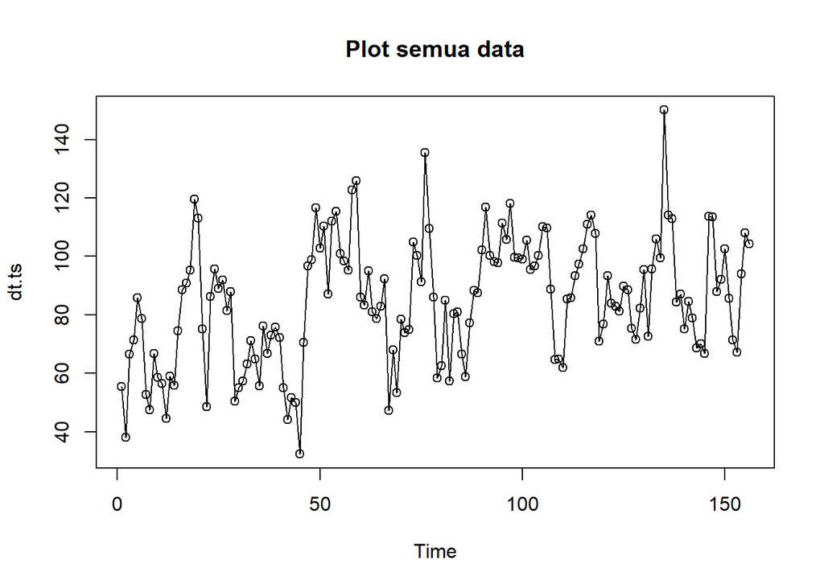

```r
#eksplorasi data
plot(dt.ts, col="black",main="Plot semua data")
points(dt.ts)
```

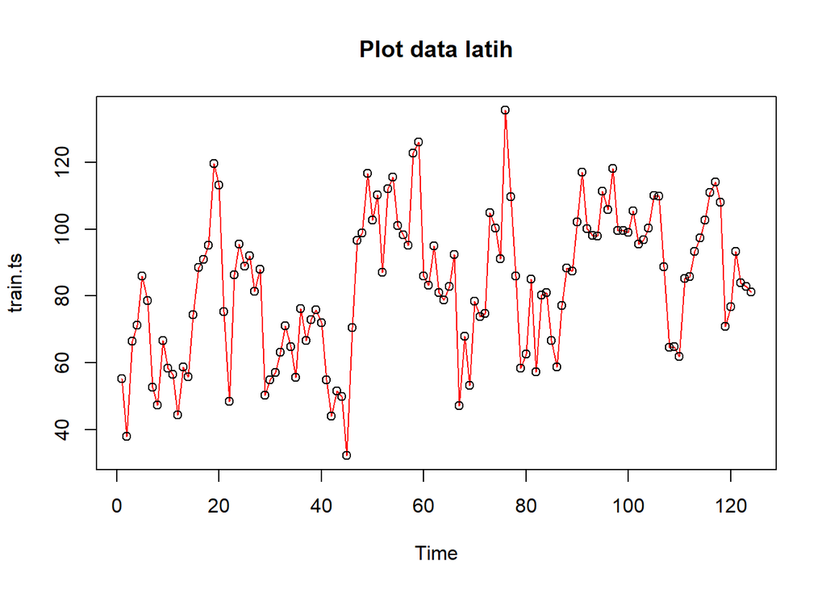

```r
plot(train.ts, col="red",main="Plot data latih")
points(train.ts)
```

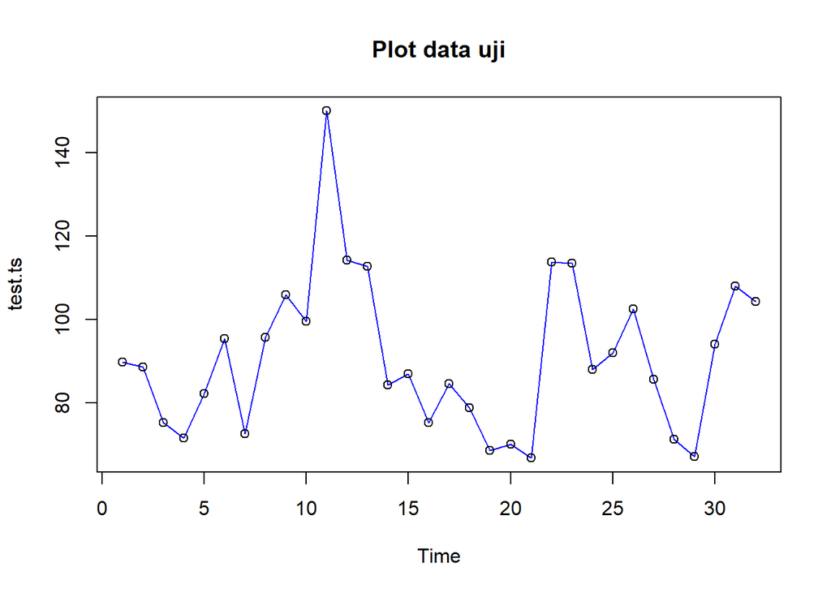

```r
plot(test.ts, col="blue",main="Plot data uji")
points(test.ts)
```

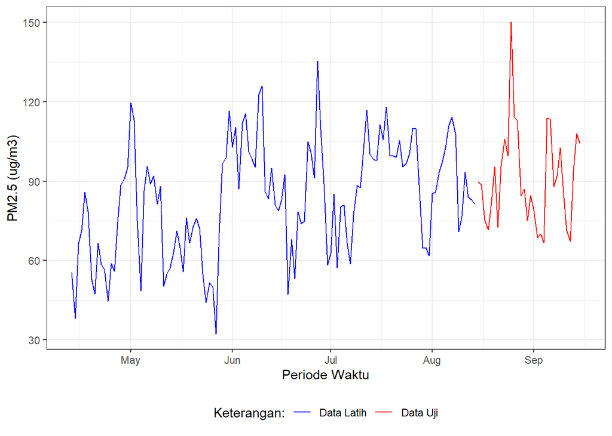

```r
# Eksplorasi dengan GGPLOT
library(ggplot2)

ggplot() +
  geom_line(
    data = training,
    aes(x = Tanggal, y = `PM2.5 (ug/m3)`, col = "Data Latih")
  ) +
  geom_line(
    data = testing,
    aes(x = Tanggal, y = `PM2.5 (ug/m3)`, col = "Data Uji")
  ) +
  labs(
    x = "Periode Waktu",
    y = "PM2.5 (ug/m3)",
    color = "Legend"
  ) +
  scale_colour_manual(
    name = "Keterangan:",
    breaks = c("Data Latih", "Data Uji"),
    values = c("blue", "red")
  ) +
  theme_bw() +
  theme(
    legend.position = "bottom",
    plot.caption = element_text(hjust = 0.5, size = 12)
  )
```

## Single Exponential Smoothing

Single Exponential Smoothing (SES) adalah metode peramalan deret waktu yang dikembangkan untuk mengatasi kelemahan Moving Average. Jika pada Moving Average setiap data periode sebelumnya dianggap memiliki bobot yang sama, maka SES memberikan bobot yang semakin mengecil secara eksponensial terhadap data lama, sehingga data terbaru diberi bobot lebih besar.

Single Exponential Smoothing merupakan metode pemulusan yang tepat digunakan untuk data dengan pola stasioner atau konstan.

Nilai pemulusan pada periode ke-t didapat dari persamaan:

$$\tilde{y}_T=\lambda
y_t+(1-\lambda)\tilde{y}_{T-1}$$

Nilai parameter $\lambda$ adalah nilai antara 0 dan 1.

Nilai pemulusan periode ke-t bertindak sebagai nilai ramalan pada periode ke-$(T+\tau)$.

$$\tilde{y}_{T+\tau}(T)=\tilde{y}_T$$

Pemulusan dengan metode SES dapat dilakukan dengan dua fungsi dari *packages* berbeda, yaitu (1) fungsi `ses()` dari *packages* `forecast` dan (2) fungsi `HoltWinters` dari *packages* `stats` .

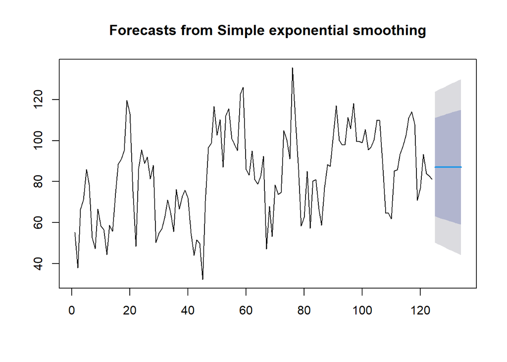

```r
#Cara 1 (fungsi ses)
ses.1 <- ses(train.ts, h = 10, alpha = 0.2)
plot(ses.1)
```

```r
ses.1
```

```
##     Point Forecast    Lo 80    Hi 80    Lo 95    Hi 95
## 125        87.0923 63.12081 111.0638 50.43107 123.7535
## 126        87.0923 62.64608 111.5385 49.70503 124.4796
## 127        87.0923 62.18039 112.0042 48.99283 125.1918
## 128        87.0923 61.72326 112.4613 48.29370 125.8909
## 129        87.0923 61.27421 112.9104 47.60694 126.5777
## 130        87.0923 60.83284 113.3518 46.93193 127.2527
## 131        87.0923 60.39877 113.7858 46.26808 127.9165
## 132        87.0923 59.97165 114.2129 45.61485 128.5697
## 133        87.0923 59.55115 114.6334 44.97175 129.2128
## 134        87.0923 59.13697 115.0476 44.33832 129.8463
```

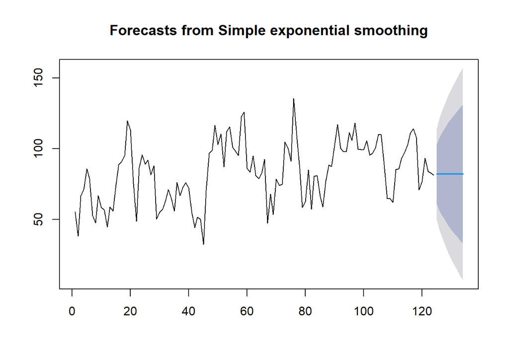

```r
ses.2<- ses(train.ts, h = 10, alpha = 0.7)
plot(ses.2)
```

```r
ses.2
```

```
##     Point Forecast    Lo 80    Hi 80     Lo 95    Hi 95
## 125       81.93052 60.82599 103.0351 49.653921 114.2071
## 126       81.93052 56.16915 107.6919 42.531910 121.3291
## 127       81.93052 52.23381 111.6272 36.513319 127.3477
## 128       81.93052 48.76214 115.0989 31.203862 132.6572
## 129       81.93052 45.62091 118.2401 26.399758 137.4613
## 130       81.93052 42.73059 121.1305 21.979396 141.8817
## 131       81.93052 40.03922 123.8218 17.863298 145.9977
## 132       81.93052 37.51061 126.3504 13.996135 149.8649
## 133       81.93052 35.11840 128.7426 10.337557 153.5235
## 134       81.93052 32.84263 131.0184  6.857062 157.0040
```

Pada fungsi `ses()` , terdapat beberapa argumen yang umum digunakan, yaitu

- `y` : nilai data deret waktu
- `alpha` : parameter pemulusan utama (0–1), mengatur bobot data terbaru vs data lama.
- `beta` : parameter pemulusan tren.
- `gamma` : parameter pemulusan musiman.
- `h` : jumlah periode ke depan yang ingin diramalkan (forecast horizon).

  Kasus di atas merupakan contoh inisialisasi nilai parameter $\lambda$ dengan nilai `alpha` 0,2 dan 0,7 dan banyak periode data yang akan diramalkan adalah sebanyak 10 periode.

Untuk mendapatkan gambar hasil pemulusan pada data latih dengan fungsi `ses()` , perlu digunakan fungsi `autoplot()` dan `autolayer()` dari *library packages* `ggplot2` .

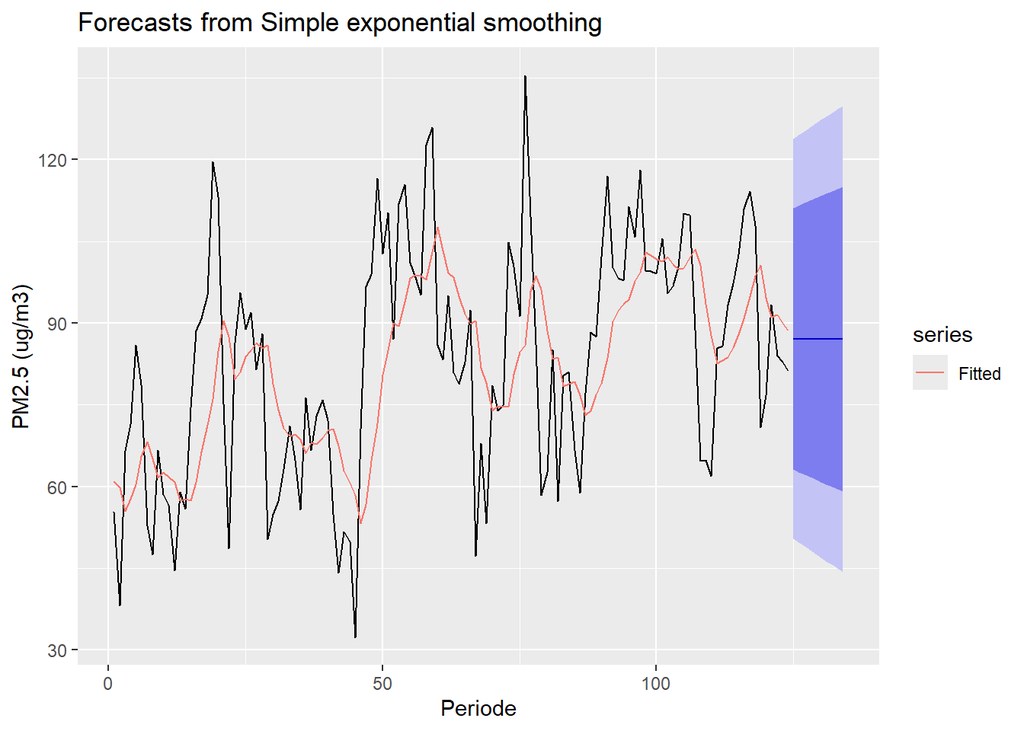

```r
autoplot(ses.1) +
  autolayer(fitted(ses.1), series = "Fitted") +
  ylab("PM2.5 (ug/m3)") +
  xlab("Periode")
```

Selanjutnya akan digunakan fungsi `HoltWinters()` dengan nilai inisialisasi parameter dan panjang periode peramalan yang sama dengan fungsi `ses()` .

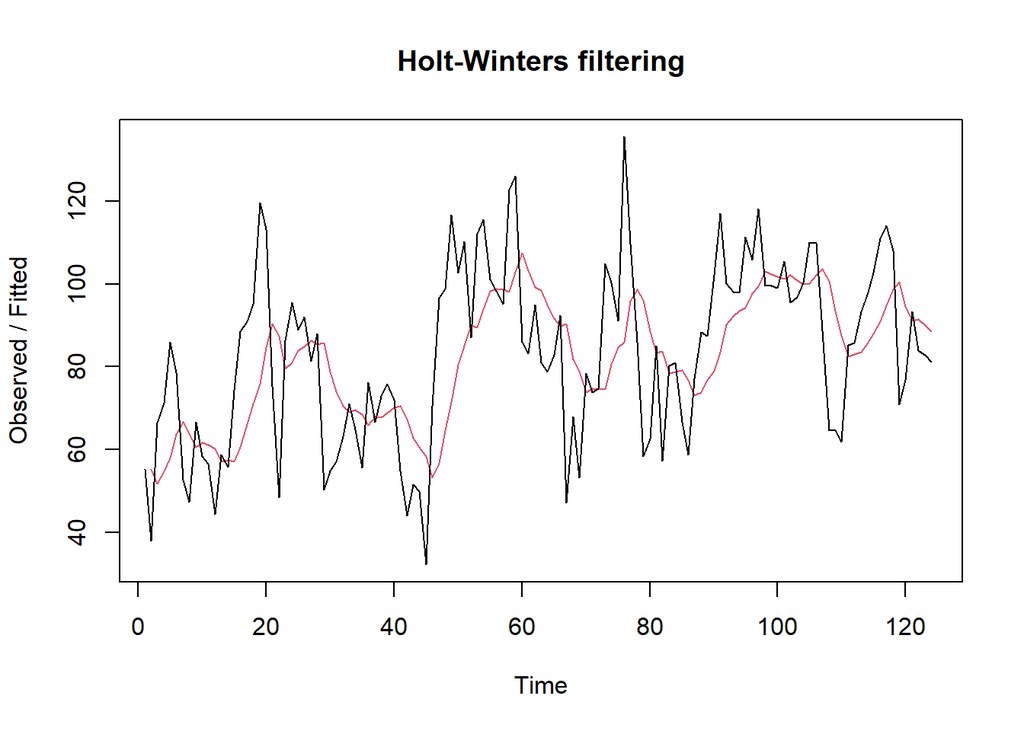

```r
#Cara 2 (fungsi Holtwinter)
ses1<- HoltWinters(train.ts, gamma = FALSE, beta = FALSE, alpha = 0.2)
plot(ses1)
```

```r
#ramalan
ramalan1<- forecast(ses1, h=10)
ramalan1
```

```
##     Point Forecast    Lo 80    Hi 80    Lo 95    Hi 95
## 125        87.0923 63.15358 111.0310 50.48119 123.7034
## 126        87.0923 62.67950 111.5051 49.75615 124.4284
## 127        87.0923 62.21446 111.9701 49.04492 125.1397
## 128        87.0923 61.75794 112.4267 48.34675 125.8378
## 129        87.0923 61.30951 112.8751 47.66093 126.5237
## 130        87.0923 60.86875 113.3158 46.98684 127.1978
## 131        87.0923 60.43527 113.7493 46.32390 127.8607
## 132        87.0923 60.00873 114.1759 45.67156 128.5130
## 133        87.0923 59.58881 114.5958 45.02934 129.1553
## 134        87.0923 59.17520 115.0094 44.39678 129.7878
```

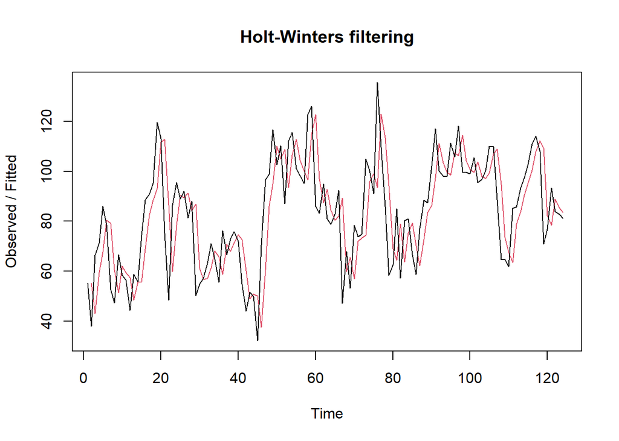

```r
ses2<- HoltWinters(train.ts, gamma = FALSE, beta = FALSE, alpha = 0.7)
plot(ses2)
```

```r
#ramalan
ramalan2<- forecast(ses2, h=10)
ramalan2
```

```
##     Point Forecast    Lo 80    Hi 80     Lo 95    Hi 95
## 125       81.93052 60.82770 103.0334 49.656533 114.2045
## 126       81.93052 56.17124 107.6898 42.535098 121.3259
## 127       81.93052 52.23621 111.6248 36.516994 127.3441
## 128       81.93052 48.76483 115.0962 31.207967 132.6531
## 129       81.93052 45.62385 118.2372 26.404251 137.4568
## 130       81.93052 42.73376 121.1273 21.984248 141.8768
## 131       81.93052 40.04261 123.8184 17.868482 145.9926
## 132       81.93052 37.51421 126.3468 14.001633 149.8594
## 133       81.93052 35.12219 128.7389 10.343351 153.5177
## 134       81.93052 32.84660 131.0144  6.863138 156.9979
```

Fungsi `HoltWinters` memiliki argumen yang sama dengan fungsi `ses()` . Argumen-argumen kedua fungsi dapat dilihat lebih lanjut dengan `?ses()` atau `?HoltWinters` .

Nilai parameter $\alpha$ dari kedua fungsi dapat dioptimalkan menyesuaikan dari *error*-nya paling minimumnya. Caranya adalah dengan membuat parameter $\alpha =$ `NULL` .

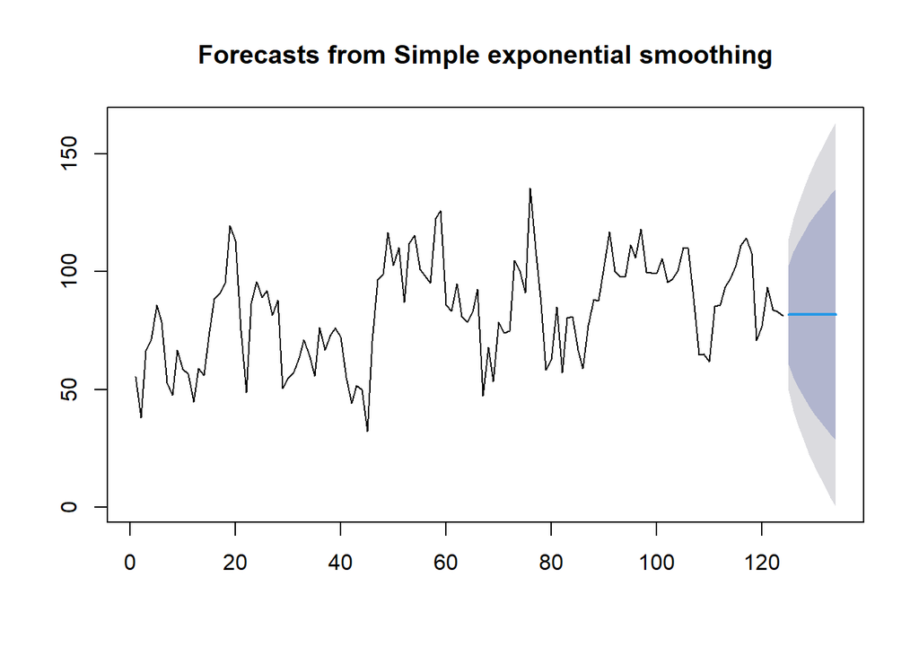

```r
#SES
ses.opt <- ses(train.ts, h = 10, alpha = NULL)
plot(ses.opt)
```

```r
ses.opt
```

```
##     Point Forecast    Lo 80    Hi 80      Lo 95    Hi 95
## 125       81.69764 60.63026 102.7650 49.4778590 113.9174
## 126       81.69764 55.05610 108.3392 40.9529261 122.4423
## 127       81.69764 50.46131 112.9340 33.9257956 129.4695
## 128       81.69764 46.46065 116.9346 27.8073206 135.5880
## 129       81.69764 42.87005 120.5252 22.3159599 141.0793
## 130       81.69764 39.58447 123.8108 17.2911082 146.1042
## 131       81.69764 36.53731 126.8580 12.6308699 150.7644
## 132       81.69764 33.68314 129.7121  8.2657931 155.1295
## 133       81.69764 30.98936 132.4059  4.1460215 159.2493
## 134       81.69764 28.43164 134.9636  0.2343296 163.1609
```

```r
#Lamda Optimum Holt Winter
HWopt<- HoltWinters(train.ts, gamma = FALSE, beta = FALSE,alpha = NULL)
HWopt
```

```
## Holt-Winters exponential smoothing without trend and without seasonal component.
##
## Call:
## HoltWinters(x = train.ts, alpha = NULL, beta = FALSE, gamma = FALSE)
##
## Smoothing parameters:
##  alpha: 0.7746603
##  beta : FALSE
##  gamma: FALSE
##
## Coefficients:
##       [,1]
## a 81.69592
```

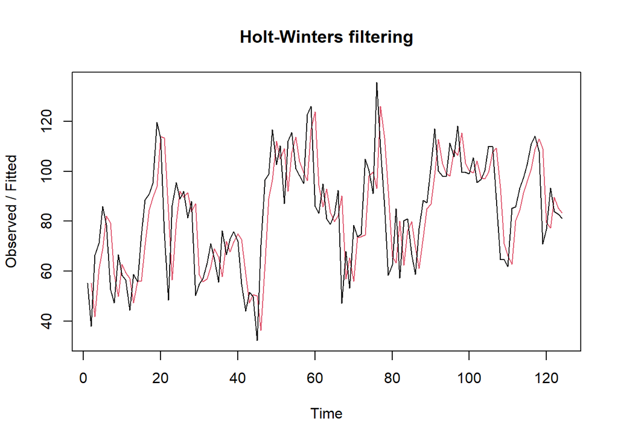

```r
plot(HWopt)
```

```r
#ramalan
ramalanopt<- forecast(HWopt, h=10)
ramalanopt
```

```
##     Point Forecast    Lo 80    Hi 80      Lo 95    Hi 95
## 125       81.69592 60.62966 102.7622 49.4778627 113.9140
## 126       81.69592 55.04816 108.3437 40.9416894 122.4501
## 127       81.69592 50.44821 112.9436 33.9066808 129.4851
## 128       81.69592 46.44347 116.9484 27.7819566 135.6099
## 129       81.69592 42.84941 120.5424 22.2853190 141.1065
## 130       81.69592 39.56082 123.8310 17.2558426 146.1360
## 131       81.69592 36.51093 126.8809 12.5914511 150.8004
## 132       81.69592 33.65428 129.7375  8.2225801 155.1693
## 133       81.69592 30.95821 132.4336  4.0992981 159.2925
## 134       81.69592 28.39835 134.9935  0.1843271 163.2075
```

Setelah dilakukan peramalan, akan dilakukan perhitungan keakuratan hasil peramalan. Perhitungan akurasi ini dilakukan baik pada data latih dan data uji.

#### Akurasi Data Latih

Perhitungan akurasi data dapat dilakukan dengan cara langsung maupun manual. Secara langsung, nilai akurasi dapat diambil dari objek yang tersimpan pada hasil SES, yaitu *sum of squared errors* (SSE). Nilai akurasi lain dapat dihitung pula dari nilai SSE tersebut.

```r
#Keakuratan Metode
#Pada data training

# SES dengan alpha = 0.2
SSE1<-ses1$SSE
MSE1<-ses1$SSE/length(train.ts)
RMSE1<-sqrt(MSE1)

akurasi1 <- matrix(c(SSE1,MSE1,RMSE1))
row.names(akurasi1)<- c("SSE", "MSE", "RMSE")
colnames(akurasi1) <- c("Akurasi lamda=0.2")
akurasi1
```

```
##      Akurasi lamda=0.2
## SSE        42773.43825
## MSE          344.94708
## RMSE          18.57275
```

```r
# SES dengan alpha = 0.7
SSE2<-ses2$SSE
MSE2<-ses2$SSE/length(train.ts)
RMSE2<-sqrt(MSE2)

akurasi2 <- matrix(c(SSE2,MSE2,RMSE2))
row.names(akurasi2)<- c("SSE", "MSE", "RMSE")
colnames(akurasi2) <- c("Akurasi lamda=0.7")
akurasi2
```

```
##      Akurasi lamda=0.7
## SSE        33091.99039
## MSE          266.87089
## RMSE          16.33618
```

```r
# Cara Manual
# Alpha = 0.2
fitted1 <- ramalan1$fitted
sisaan1 <- ramalan1$residuals
head(sisaan1)
```

```
## Time Series:
## Start = 1
## End = 6
## Frequency = 1
## [1]        NA -17.25000  14.57920  16.54256  27.75905  14.99884
```

```r
resid1 <- training$`PM2.5 (ug/m3)` - ramalan1$fitted
head(resid1)
```

```
## Time Series:
## Start = 1
## End = 6
## Frequency = 1
## [1]        NA -17.25000  14.57920  16.54256  27.75905  14.99884
```

```r
SSE.1 <- sum(sisaan1[2:length(train.ts)]^2)
SSE.1
```

```
## [1] 42773.44
```

```r
MSE.1 <- SSE.1 / length(train.ts)
MSE.1
```

```
## [1] 344.9471
```

```r
MAPE.1 <- sum(
  abs(sisaan1[2:length(train.ts)] / train.ts[2:length(train.ts)]) * 100
) / length(train.ts)
MAPE.1
```

```
## [1] 19.42642
```

```r
akurasi.1 <- matrix(c(SSE.1, MSE.1, MAPE.1))
row.names(akurasi.1) <- c("SSE", "MSE", "MAPE")
colnames(akurasi.1) <- c("Akurasi alpha=0.2")
akurasi.1
```

```
##      Akurasi alpha=0.2
## SSE        42773.43825
## MSE          344.94708
## MAPE          19.42642
```

```r
# Alpha = 0.7
fitted2 <- ramalan2$fitted
sisaan2 <- ramalan2$residuals
head(sisaan2)
```

```
## Time Series:
## Start = 1
## End = 6
## Frequency = 1
## [1]         NA -17.250000  23.204200  11.840460  18.077138  -1.785259
```

```r
resid2 <- training$`PM2.5 (ug/m3)` - ramalan2$fitted
head(resid2)
```

```
## Time Series:
## Start = 1
## End = 6
## Frequency = 1
## [1]         NA -17.250000  23.204200  11.840460  18.077138  -1.785259
```

```r
SSE.2 <- sum(sisaan2[2:length(train.ts)]^2)
SSE.2
```

```
## [1] 33091.99
```

```r
MSE.2 <- SSE.2 / length(train.ts)
MSE.2
```

```
## [1] 266.8709
```

```r
MAPE.2 <- sum(
  abs(sisaan2[2:length(train.ts)] / train.ts[2:length(train.ts)]) * 100
) / length(train.ts)
MAPE.2
```

```
## [1] 16.97318
```

```r
akurasi.2 <- matrix(c(SSE.2, MSE.2, MAPE.2))
row.names(akurasi.2) <- c("SSE", "MSE", "MAPE")
colnames(akurasi.2) <- c("Akurasi alpha=0.7")
akurasi.2
```

```
##      Akurasi alpha=0.7
## SSE        33091.99039
## MSE          266.87089
## MAPE          16.97318
```

Berdasarkan nilai SSE, MSE, RMSE, dan MAPE di antara kedua parameter, nilai parameter $\lambda=0,7$ menghasilkan akurasi yang lebih baik dibanding $\lambda=0,2$ . Hal ini dilihat dari nilai masing-masing ukuran akurasi yang lebih kecil. Berdasarkan nilai MAPE-nya, hasil ini dapat dikategorikan sebagai peramalan baik.

#### Akurasi Data Uji

Akurasi data uji dapat dihitung dengan cara yang hampir sama dengan perhitungan akurasi data latih.

```r
# jumlah observasi uji
n_test <- nrow(testing)

# error (ramalan - aktual)
e1 <- as.numeric(ramalan1$mean)[1:n_test] -
      as.numeric(testing$`PM2.5 (ug/m3)`)

e2 <- as.numeric(ramalan2$mean)[1:n_test] -
      as.numeric(testing$`PM2.5 (ug/m3)`)

eopt <- as.numeric(ramalanopt$mean)[1:n_test] -
        as.numeric(testing$`PM2.5 (ug/m3)`)

# SSE / MSE / RMSE untuk masing-masing model
SSEtesting1  <- sum(e1^2, na.rm = TRUE)
MSEtesting1  <- mean(e1^2, na.rm = TRUE)
RMSEtesting1 <- sqrt(MSEtesting1)

SSEtesting2  <- sum(e2^2, na.rm = TRUE)
MSEtesting2  <- mean(e2^2, na.rm = TRUE)
RMSEtesting2 <- sqrt(MSEtesting2)

SSEtestingopt  <- sum(eopt^2, na.rm = TRUE)
MSEtestingopt  <- mean(eopt^2, na.rm = TRUE)
RMSEtestingopt <- sqrt(MSEtestingopt)

# Tabel ringkas
akurasitesting_SSE <- matrix(
  c(SSEtesting1, SSEtesting2, SSEtestingopt),
  nrow = 3,
  dimnames = list(c("SSE1", "SSE2", "SSEopt"), "Nilai")
)

akurasitesting_MSE <- matrix(
  c(MSEtesting1, MSEtesting2, MSEtestingopt),
  nrow = 3,
  dimnames = list(c("MSE1", "MSE2", "MSEopt"), "Nilai")
)

akurasitesting_RMSE <- matrix(
  c(RMSEtesting1, RMSEtesting2, RMSEtestingopt),
  nrow = 3,
  dimnames = list(c("RMSE1", "RMSE2", "RMSEopt"), "Nilai")
)

akurasitesting_SSE
```

```
##           Nilai
## SSE1   1277.354
## SSE2   1603.822
## SSEopt 1631.320
```

```r
akurasitesting_MSE
```

```
##           Nilai
## MSE1   127.7354
## MSE2   160.3822
## MSEopt 163.1320
```

```r
akurasitesting_RMSE
```

```
##            Nilai
## RMSE1   11.30201
## RMSE2   12.66421
## RMSEopt 12.77231
```

Selain dengan cara di atas, perhitungan nilai akurasi dapat menggunakan fungsi `accuracy()` dari *package* `forecast` . Penggunaannya yaitu dengan menuliskan `accuracy(hasil ramalan, kondisi aktual)` . Contohnya adalah sebagai berikut.

```r
ramalan1 <- ses(train.ts, alpha = 0.2, h = nrow(testing))
ramalan2 <- ses(train.ts, alpha = 0.7, h = nrow(testing))
ramalanopt <- ses(train.ts, h = nrow(testing))
```

```r
accuracy(ramalan1, testing$`PM2.5 (ug/m3)`)
```

```
##                    ME     RMSE      MAE        MPE     MAPE     MASE      ACF1
## Training set 1.053848 18.55359 14.64532 -3.8474779 19.53749 1.161219 0.5239662
## Test set     3.842212 18.54921 14.14463  0.6922081 15.10376 1.121519        NA
```

```r
accuracy(ramalan2, testing$`PM2.5 (ug/m3)`)
```

```
##                     ME     RMSE      MAE       MPE     MAPE     MASE      ACF1
## Training set 0.3338884 16.33461 12.67300 -2.677942 16.99632 1.004835 0.1020369
## Test set     9.0039861 20.25789 15.36421  6.577969 15.62627 1.218219        NA
```

```r
accuracy(ramalanopt, testing$`PM2.5 (ug/m3)`)
```

```
##                     ME     RMSE      MAE       MPE     MAPE      MASE
## Training set 0.2992164 16.30585 12.54326 -2.558065 16.81766 0.9945475
## Test set     9.2368716 20.36247 15.45155  6.843519 15.68845 1.2251437
##                    ACF1
## Training set 0.04145154
## Test set             NA
```

## *Double Exponential Smoothing* (DES)

Metode pemulusan *Double Exponential Smoothing* (DES) digunakan untuk data yang memiliki pola tren. Metode DES adalah metode semacam SES, hanya saja dilakukan dua kali, yaitu pertama untuk tahapan ‘level’ dan kedua untuk tahapan ‘tren’. Pemulusan menggunakan metode ini akan menghasilkan peramalan tidak konstan untuk periode berikutnya.

Pemulusan dengan metode DES kali ini akan menggunakan fungsi `HoltWinters()` . Jika sebelumnya nilai argumen `beta` dibuat `FALSE` , kali ini argumen tersebut akan diinisialisasi bersamaan dengan nilai `alpha` .

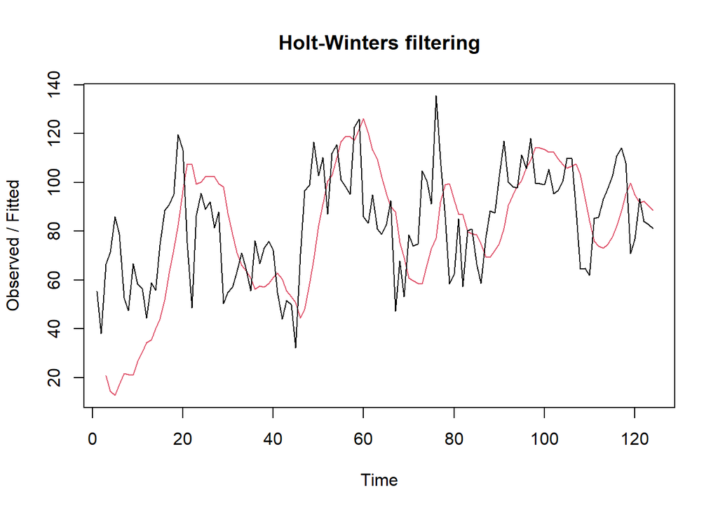

```r
#Lamda=0.2 dan gamma=0.2
des.1<- HoltWinters(train.ts, gamma = FALSE, beta = 0.2, alpha = 0.2)
plot(des.1)
```

```r
#ramalan
ramalandes1<- forecast(des.1, h=10)
ramalandes1
```

```
##     Point Forecast    Lo 80    Hi 80     Lo 95    Hi 95
## 125       86.55651 54.36296 118.7501 37.320726 135.7923
## 126       85.92376 52.81601 119.0315 35.289830 136.5577
## 127       85.29100 50.97805 119.6039 32.813872 137.7681
## 128       84.65824 48.83216 120.4843 29.866973 139.4495
## 129       84.02549 46.37141 121.6796 26.438554 141.6124
## 130       83.39273 43.59754 123.1879 22.531241 144.2542
## 131       82.75997 40.51889 125.0011 18.157815 147.3621
## 132       82.12721 37.14832 127.1061 13.337930 150.9165
## 133       81.49446 33.50123 129.4877  8.095144 154.8938
## 134       80.86170 29.59404 132.1294  2.454579 159.2688
```

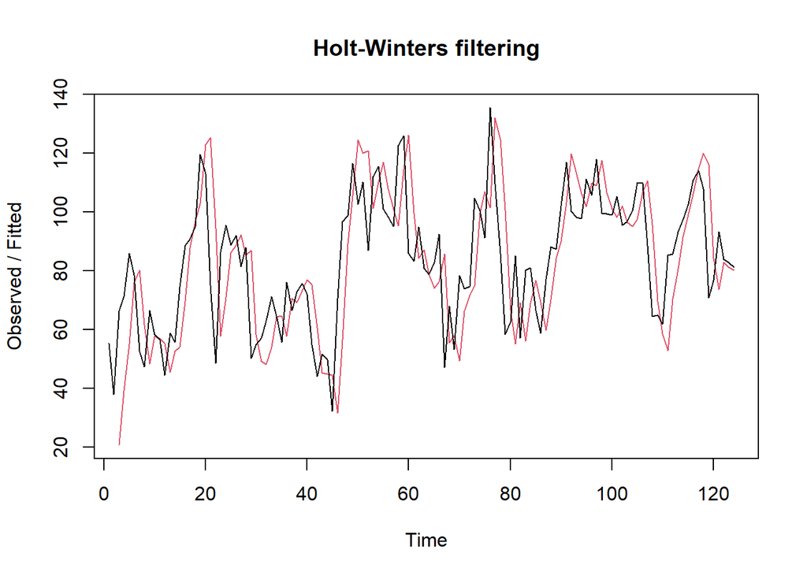

```r
#Lamda=0.6 dan gamma=0.3
des.2<- HoltWinters(train.ts, gamma = FALSE, beta = 0.3, alpha = 0.6)
plot(des.2)
```

```r
#ramalan
ramalandes2<- forecast(des.2, h=10)
ramalandes2
```

```
##     Point Forecast     Lo 80    Hi 80        Lo 95    Hi 95
## 125       78.92136  54.50858 103.3341   41.5852385 116.2575
## 126       77.06114  46.10020 108.0221   29.7104675 124.4118
## 127       75.20093  36.37004 114.0318   15.8142014 134.5877
## 128       73.34072  25.56647 121.1150    0.2763131 146.4051
## 129       71.48051  13.85395 129.1071  -16.6517120 159.6127
## 130       69.62029   1.34304 137.8975  -34.8007553 174.0413
## 131       67.76008 -11.88844 147.4086  -54.0518248 189.5720
## 132       65.89987 -25.78302 157.5828  -74.3170097 206.1167
## 133       64.03966 -40.29633 168.3756  -95.5284592 223.6078
## 134       62.17944 -55.39284 179.7517 -117.6318520 241.9907
```

Selanjutnya jika ingin membandingkan plot data latih dan data uji adalah sebagai berikut.

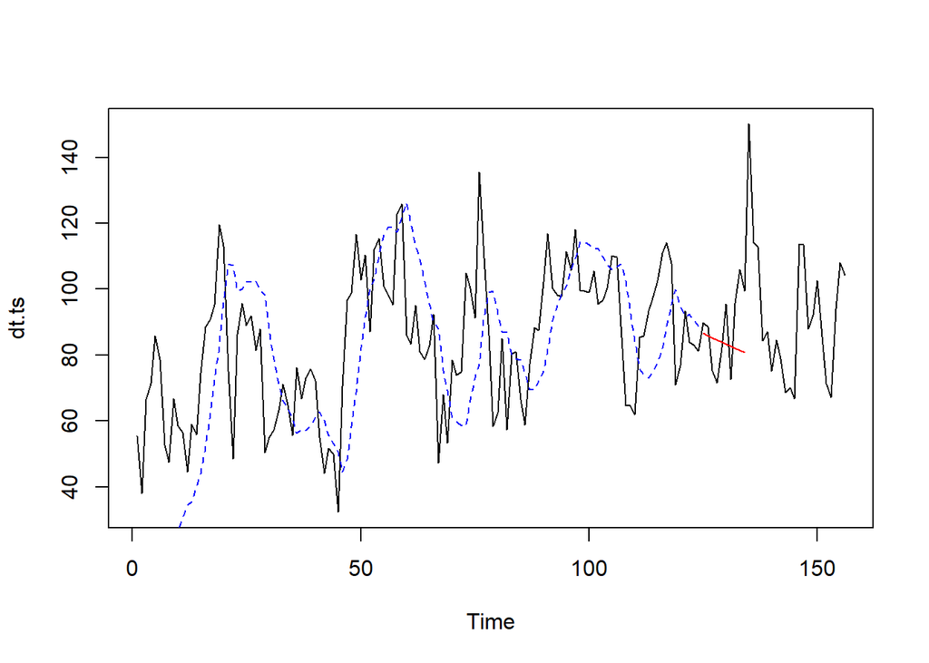

```r
plot(dt.ts)
lines(des.1$fitted[,1], lty=2, col="blue")
lines(ramalandes1$mean, col="red")
```

Untuk mendapatkan nilai parameter optimum dari DES, argumen `alpha` dan `beta` dapat dibuat `NULL` seperti berikut.

```r
#Lamda dan gamma optimum
des.opt<- HoltWinters(train.ts, gamma = FALSE)
des.opt
```

```
## Holt-Winters exponential smoothing with trend and without seasonal component.
##
## Call:
## HoltWinters(x = train.ts, gamma = FALSE)
##
## Smoothing parameters:
##  alpha: 0.9044641
##  beta : 0.08063459
##  gamma: FALSE
##
## Coefficients:
##         [,1]
## a 81.2984244
## b -0.7847141
```

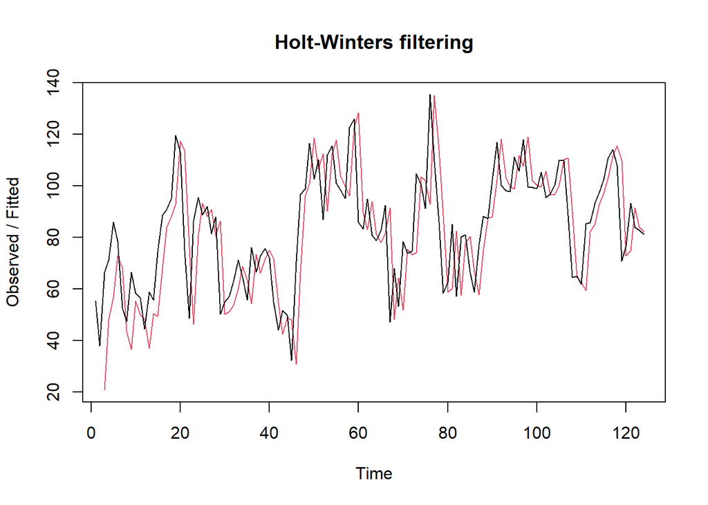

```r
plot(des.opt)
```

```r
#ramalan
ramalandesopt<- forecast(des.opt, h=10)
ramalandesopt
```

```
##     Point Forecast       Lo 80    Hi 80      Lo 95    Hi 95
## 125       80.51371  57.7822097 103.2452  45.748880 115.2785
## 126       79.72900  47.9430641 111.5149  31.116608 128.3414
## 127       78.94428  39.1902309 118.6983  18.145707 139.7429
## 128       78.15957  30.9119726 125.4072   5.900606 150.4185
## 129       77.37485  22.8616047 131.8881  -5.995966 160.7457
## 130       76.59014  14.9138994 138.2664 -17.735530 170.9158
## 131       75.80543   6.9968146 144.6140 -29.428264 181.0391
## 132       75.02071  -0.9344735 150.9759 -41.142720 191.1841
## 133       74.23600  -8.9093632 157.3814 -52.923858 201.3959
## 134       73.45128 -16.9478558 163.8504 -64.802269 211.7048
```

Selanjutnya akan dilakukan perhitungan akurasi pada data latih maupun data uji dengan ukuran akurasi SSE, MSE dan MAPE.

#### Akurasi Data Latih

```r
#Akurasi Data Training
ssedes.train1<-des.1$SSE
msedes.train1<-ssedes.train1/length(train.ts)
sisaandes1<-ramalandes1$residuals
head(sisaandes1)
```

```
## Time Series:
## Start = 1
## End = 6
## Frequency = 1
## [1]       NA       NA 45.62920 56.80739 73.12345 61.51796
```

```r
mapedes.train1 <- sum(abs(sisaandes1[3:length(train.ts)]/train.ts[3:length(train.ts)])
                      *100)/length(train.ts)

akurasides.1 <- matrix(c(ssedes.train1,msedes.train1,mapedes.train1))
row.names(akurasides.1)<- c("SSE", "MSE", "MAPE")
colnames(akurasides.1) <- c("Akurasi lamda=0.2 dan gamma=0.2")
akurasides.1
```

```
##      Akurasi lamda=0.2 dan gamma=0.2
## SSE                      77771.98412
## MSE                        627.19342
## MAPE                        26.48359
```

```r
ssedes.train2<-des.2$SSE
msedes.train2<-ssedes.train2/length(train.ts)
sisaandes2<-ramalandes2$residuals
head(sisaandes2)
```

```
## Time Series:
## Start = 1
## End = 6
## Frequency = 1
## [1]        NA        NA 45.629200 32.167624 30.638621  2.778668
```

```r
mapedes.train2 <- sum(abs(sisaandes2[3:length(train.ts)]/train.ts[3:length(train.ts)])
                      *100)/length(train.ts)

akurasides.2 <- matrix(c(ssedes.train2,msedes.train2,mapedes.train2))
row.names(akurasides.2)<- c("SSE", "MSE", "MAPE")
colnames(akurasides.2) <- c("Akurasi lamda=0.6 dan gamma=0.3")
akurasides.2
```

```
##      Akurasi lamda=0.6 dan gamma=0.3
## SSE                      43968.30480
## MSE                        354.58310
## MAPE                        18.82872
```

#### Akurasi Data Uji

```r
ramalandes1 <- forecast(des.1, h = nrow(testing))
ramalandes2 <- forecast(des.2, h = nrow(testing))
ramalandesopt <- forecast(des.opt, h = nrow(testing))
```

```r
# Akurasi Data Testing
selisihdes1 <- ramalandes1$mean - testing$`PM2.5 (ug/m3)`
selisihdes1
```

```
## Time Series:
## Start = 125
## End = 156
## Frequency = 1
##  [1]  -3.185187  -2.667944   9.974299  13.033242   1.771285 -12.069772
##  [7]  10.222471 -13.589486 -24.447243 -18.688300 -69.862756 -34.612113
## [13] -33.815770  -6.061027  -9.335384   1.856859  -8.221798  -3.108655
## [19]   6.608588   4.471631   7.101374 -40.502183 -40.822440 -15.992697
## [25] -20.662954 -31.891611 -15.565968  -1.861225   1.647618 -25.872639
## [31] -40.417896 -37.375652
```

```r
SSEtestingdes1 <- sum(selisihdes1^2)
MSEtestingdes1 <- SSEtestingdes1 / length(testing$`PM2.5 (ug/m3)`)
MAPEtestingdes1 <- sum(
  abs(selisihdes1 / testing$`PM2.5 (ug/m3)`) * 100
) / length(testing$`PM2.5 (ug/m3)`)


selisihdes2 <- ramalandes2$mean - testing$`PM2.5 (ug/m3)`
selisihdes2
```

```
## Time Series:
## Start = 125
## End = 156
## Frequency = 1
##  [1] -10.8203449 -11.5305573  -0.1157696   1.7157180 -10.7736944 -25.8422067
##  [7]  -4.7774191 -29.8168314 -41.9020438 -37.3705561 -89.7724685 -55.7492809
## [13] -56.1803932 -29.6531056 -34.1549179 -24.1901303 -35.4962427 -31.6105550
## [19] -23.1207674 -26.4851797 -25.0828921 -73.9139044 -75.4616168 -51.8593292
## [25] -57.7570415 -70.2131539 -55.1149662 -42.6376786 -40.3562910 -69.1040033
## [31] -84.8767157 -83.0619280
```

```r
SSEtestingdes2 <- sum(selisihdes2^2)
MSEtestingdes2 <- SSEtestingdes2 / length(testing$`PM2.5 (ug/m3)`)
MAPEtestingdes2 <- sum(
  abs(selisihdes2 / testing$`PM2.5 (ug/m3)`) * 100
) / length(testing$`PM2.5 (ug/m3)`)


selisihdesopt <- ramalandesopt$mean - testing$`PM2.5 (ug/m3)`
selisihdesopt
```

```
## Time Series:
## Start = 125
## End = 156
## Frequency = 1
##  [1]  -9.227990  -8.862704   3.627582   6.534568  -4.879346 -18.872360
##  [7]   3.267926 -20.695988 -31.705703 -26.098717 -77.425131 -42.326445
## [13] -41.682059 -14.079273 -17.505587  -6.465301 -16.695915 -11.734729
## [19]  -2.169443  -4.458358  -1.980572 -49.736086 -50.208300 -25.530514
## [25] -30.352728 -41.733342 -25.559656 -12.006870  -8.649984 -36.322199
## [31] -51.019413 -48.129127
```

```r
SSEtestingdesopt <- sum(selisihdesopt^2)
MSEtestingdesopt <- SSEtestingdesopt / length(testing$`PM2.5 (ug/m3)`)
MAPEtestingdesopt <- sum(
  abs(selisihdesopt / testing$`PM2.5 (ug/m3)`) * 100
) / length(testing$`PM2.5 (ug/m3)`)


akurasitestingdes <- matrix(
  c(
    SSEtestingdes1, MSEtestingdes1, MAPEtestingdes1,
    SSEtestingdes2, MSEtestingdes2, MAPEtestingdes2,
    SSEtestingdesopt, MSEtestingdesopt, MAPEtestingdesopt
  ),
  nrow = 3,
  ncol = 3
)

row.names(akurasitestingdes) <- c("SSE", "MSE", "MAPE")
colnames(akurasitestingdes) <- c("DES ske1", "DES ske2", "DES opt")

akurasitestingdes
```

```
##         DES ske1    DES ske2     DES opt
## SSE  18167.64297 73655.66789 28660.24044
## MSE    567.73884  2301.73962   895.63251
## MAPE    17.42885    43.00294    23.20127
```

#### Perbandingan SES dan DES

```r
MSEfull <-
  matrix(c(MSEtesting1,MSEtesting2,MSEtestingopt,MSEtestingdes1,MSEtestingdes2,
           MSEtestingdesopt),nrow=3,ncol=2)
row.names(MSEfull)<- c("ske 1", "ske 2", "ske opt")
colnames(MSEfull) <- c("ses","des")
MSEfull
```

```
##              ses       des
## ske 1   127.7354  567.7388
## ske 2   160.3822 2301.7396
## ske opt 163.1320  895.6325
```

## Pemulusan Data Musiman

```r
# Membagi data menjadi training dan testing
n <- nrow(dt)

n_train <- floor(0.8 * n)

training <- dt[1:n_train, ]
testing <- dt[(n_train + 1):n, ]

# Membuat data deret waktu
training.ts <- ts(training$`PM2.5 (ug/m3)`, frequency = 7)
testing.ts <- ts(testing$`PM2.5 (ug/m3)`, frequency = 7)
```

Kemudian akan dilakukan eskplorasi dengan plot data deret waktu sebagai berikut.

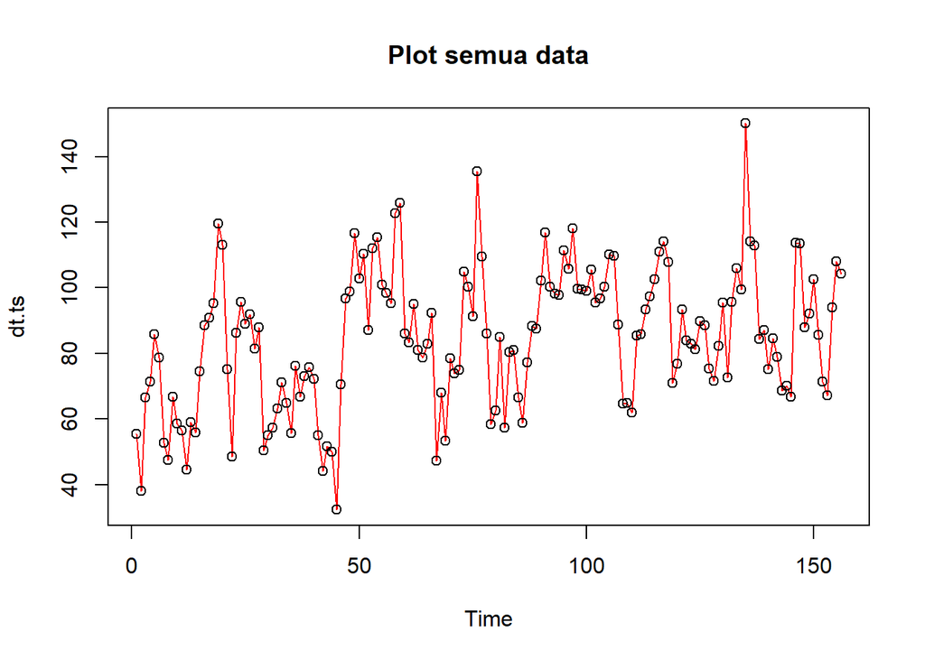

```r
#Membuat plot time series
plot(dt.ts, col="red",main="Plot semua data")
points(dt.ts)
```

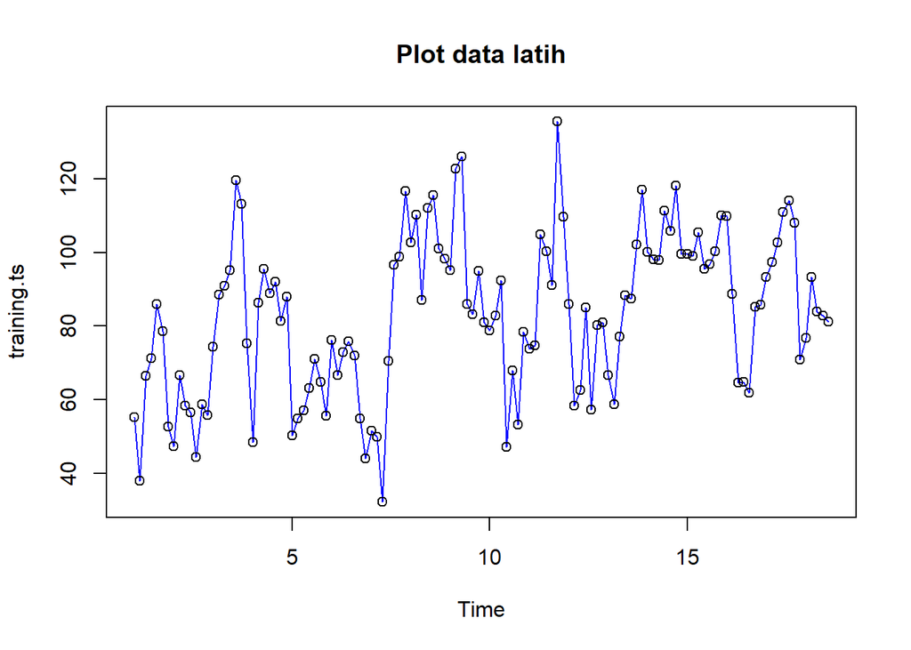

```r
plot(training.ts, col="blue",main="Plot data latih")
points(training.ts)
```

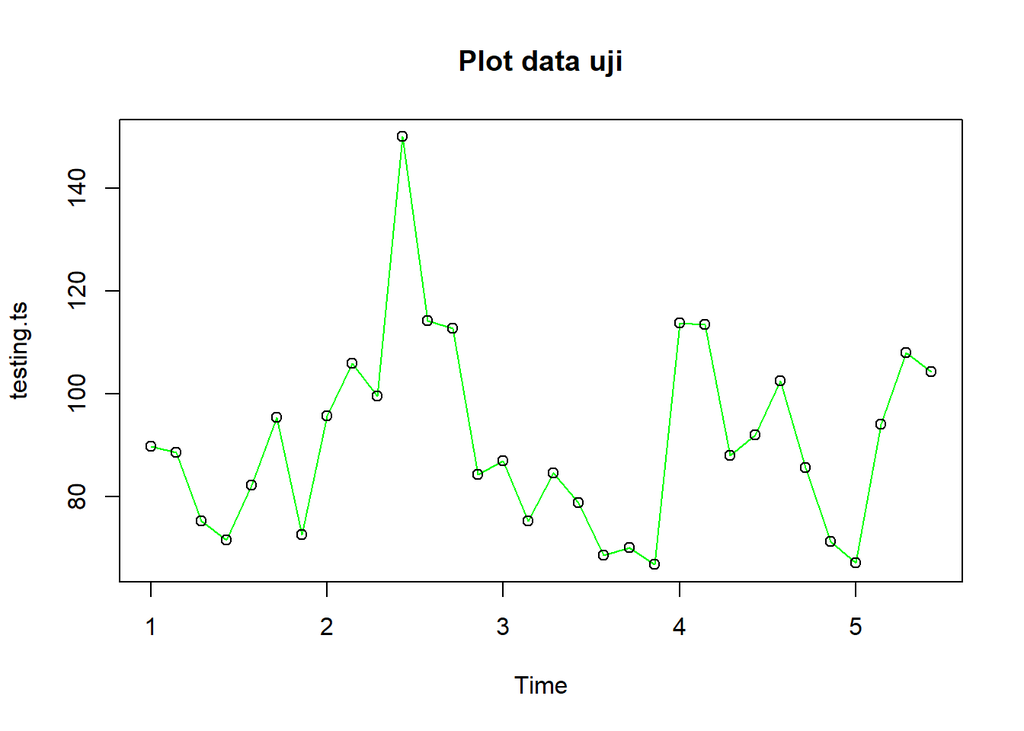

```r
plot(testing.ts, col="green",main="Plot data uji")
points(testing.ts)
```

Metode Holt-Winter untuk peramalan data musiman menggunakan tiga persamaan pemulusan yang terdiri atas persamaan untuk level $(L_t)$, trend $(B_t)$, dan komponen seasonal / musiman $(S_t)$ dengan parameter pemulusan berupa $\alpha$, $\beta$, dan $\gamma$. Metode Holt-Winter musiman terbagi menjadi dua, yaitu metode aditif dan metode multiplikatif. Perbedaan persamaan dan contoh datanya adalah sebagai berikut.

[figure not shown]

Pemulusan data musiman dengan metode Winter dilakukan menggunakan fungsi `HoltWinters()` dengan memasukkan argumen tambahan, yaitu `gamma()` dan `seasonal()` . Arguman `seasonal()` diinisialisasi menyesuaikan jenis musiman, aditif atau multiplikatif.

### Winter Aditif

Perhitungan dengan model aditif dilakukan jika plot data asli menunjukkan fluktuasi musiman yang relatif stabil (konstan).

#### Pemulusan

```r
#Pemulusan dengan winter aditif
winter1 <- HoltWinters(training.ts,alpha=0.2,beta=0.1,gamma=0.1,seasonal = "additive")
winter1$fitted
```

```
## Time Series:
## Start = c(2, 1)
## End = c(18, 5)
## Frequency = 7
##                xhat     level        trend        season
##  2.000000  47.49607  68.44898 -1.538364966 -19.414545918
##  2.142857  71.05643  66.89974 -1.539452310   5.696139796
##  2.285714  63.23205  64.47900 -1.627580852   0.380625510
##  2.428571  61.28166  61.90667 -1.722055784   1.097046939
##  2.571429  77.27527  59.24078 -1.816439042  19.850925510
##  2.714286  56.97445  50.88179 -2.470694439   8.563354082
##  2.857143  30.18773  48.79371 -2.432433440 -16.173545918
##  3.000000  30.15747  51.49539 -1.919021971 -19.418895293
##  3.142857  62.74715  58.43653 -1.033005369   5.343625624
##  3.285714  62.06087  62.57410 -0.515948399   0.002725784
##  3.428571  68.60082  67.82097  0.060334142   0.719513906
##  3.571429  91.02094  73.19530  0.591733730  17.233903922
##  3.714286  89.38624  79.50619  1.163648925   8.716398080
##  3.857143  72.94529  85.42593  1.639258219 -14.119900044
##  4.000000  73.33298  87.52279  1.685018453 -15.874828886
##  4.142857  92.85975  84.25787  1.190024848   7.411853506
##  4.285714  87.50721  84.14011  1.059245819   2.307855948
##  4.428571  90.88138  86.81541  1.220851630   2.845112257
##  4.571429 108.34735  87.64415  1.181640121  19.521564703
##  4.714286  97.02985  85.55632  0.854693062  10.618835258
##  4.857143  69.89303  83.28754  0.542346142 -13.936859110
##  5.000000  70.50279  87.45294  0.904651571 -17.854803307
##  5.142857  91.71279  84.32288  0.501179767   6.888737390
##  5.285714  80.19078  77.47066 -0.234160086   2.954279195
##  5.428571  74.63446  72.64000 -0.693809602   2.688266219
##  5.571429  86.95240  69.66096 -0.922332764  18.213776467
##  5.714286  73.71564  65.58399 -1.237796843   9.369447580
##  5.857143  48.66207  62.56556 -1.415859592 -12.487637394
##  6.000000  41.81350  62.55729 -1.275100899 -19.468690524
##  6.142857  71.52317  68.16283 -0.587036865   3.947377979
##  6.285714  67.03234  66.60116 -0.684500270   1.115681128
##  6.428571  68.31372  67.10519 -0.565647052   1.774173572
##  6.571429  84.58197  68.04514 -0.415087385  16.951920151
##  6.714286  73.12613  65.13366 -0.664726835   8.657196586
##  6.857143  47.88268  60.83537 -1.028083388 -11.924602624
```

[output cut: 67 more lines]

```
## 16.571429  96.05433  89.72905 -0.886557336   7.211834903
## 16.714286  90.14385  81.99829 -1.570977977   9.716536663
## 16.857143  78.11277  79.45938 -1.667770966   0.321157439
## 17.000000  69.90877  79.32740 -1.514192353  -7.904438239
## 17.142857  78.51667  82.48811 -1.046701702  -2.924736960
## 17.285714  81.97732  85.19808 -0.671035173  -2.549718479
## 17.428571  87.12867  88.65074 -0.258665616  -1.263404807
## 17.571429  97.84458  93.15300  0.217427069   4.474152338
## 17.714286 106.49891  96.62651  0.543035532   9.329364708
## 17.857143  98.96179  97.45476  0.571557345   0.935471890
## 18.000000  86.38523  92.40980  0.009905505  -6.034475636
## 18.142857  88.88504  90.49016 -0.183049127  -1.422070843
## 18.285714  90.19511  91.19010 -0.094749946  -0.900240250
## 18.428571  90.26397  89.84299 -0.219986214   0.640965932
## 18.571429  93.56046  88.15105 -0.367181628   5.776586192
```

```r
xhat1 <- winter1$fitted[,2]

winter1.opt<- HoltWinters(training.ts, alpha= NULL,  beta = NULL, gamma = NULL, seasonal = "additive")
winter1.opt
```

```
## Holt-Winters exponential smoothing with trend and additive seasonal component.
##
## Call:
## HoltWinters(x = training.ts, alpha = NULL, beta = NULL, gamma = NULL,     seasonal = "additive")
##
## Smoothing parameters:
##  alpha: 0.6389962
##  beta : 0.004995907
##  gamma: 0.4158226
##
## Coefficients:
##           [,1]
## a  77.71022964
## b  -0.83967902
## s1 15.60278645
## s2  7.78728124
## s3  3.43138813
## s4  0.02480913
## s5 -1.17872690
## s6  2.80416287
## s7  4.38238030
```

```r
winter1.opt$fitted
```

```
## Time Series:
## Start = c(2, 1)
## End = c(18, 5)
## Frequency = 7
##                xhat     level      trend       season
##  2.000000  47.49607  68.44898 -1.5383650 -19.41454592
##  2.142857  71.03347  66.87587 -1.5385385   5.69613980
##  2.285714  61.36440  62.53631 -1.5525322   0.38062551
##  2.428571  58.69414  59.15874 -1.5616499   1.09704694
##  2.571429  74.51745  56.23498 -1.5684549  19.85092551
##  2.714286  42.42470  35.52543 -1.6640820   8.56335408
##  2.857143  26.59594  44.38101 -1.6115267 -16.17354592
##  3.000000  40.52720  61.46802 -1.5181106 -19.42270717
##  3.142857  85.26008  81.63175 -1.4097901   5.03812094
##  3.285714  80.90891  82.35616 -1.3991279  -0.04811448
##  3.428571  86.73507  87.32532 -1.3673125   0.77705946
##  3.571429 105.36231  91.34841 -1.3403826  15.35428113
##  3.714286 108.85629  99.11653 -1.2948773  11.03464360
##  3.857143  87.51400 100.57598 -1.2811169 -11.78086893
##  4.000000  75.79804  91.44755 -1.3203214 -14.32918971
##  4.142857  76.86940  72.73711 -1.4072008   5.53948789
##  4.285714  77.44022  77.36932 -1.3770285   1.44793018
##  4.428571  88.31261  87.58833 -1.3190957   2.04337747
##  4.571429 102.83477  86.65787 -1.3171542  17.49405876
##  4.714286  88.74729  78.41733 -1.3517427  11.68169389
##  4.857143  57.37917  72.37869 -1.3751581 -13.62436809
##  5.000000  70.88356  90.57543 -1.2773787 -18.41449056
##  5.142857  81.77917  76.16389 -1.3429957   6.95827097
##  5.285714  60.41790  57.67448 -1.4286576   4.17208249
##  5.428571  54.89067  54.19490 -1.4389039   2.13467431
##  5.571429  72.52619  58.07093 -1.4123509  15.86761294
##  5.714286  64.96185  55.79786 -1.4166510  10.58064311
##  5.857143  43.84212  54.28577 -1.4171278  -9.02651991
##  6.000000  37.56653  60.44578 -1.3792731 -21.49997917
##  6.142857  85.43815  83.76382 -1.2558877   2.93021844
##  6.285714  72.87679  70.50238 -1.3158663   3.69027752
##  6.428571  71.31698  69.24927 -1.3155528   3.38326375
##  6.571429  85.18930  70.82499 -1.3011082  15.66541144
##  6.714286  70.37521  61.15988 -1.3428940  10.55822398
##  6.857143  41.32704  49.96564 -1.3921104  -7.24649205
```

[output cut: 67 more lines]

```
## 16.571429  69.60667  65.11175 -0.9658603   5.46077407
## 16.714286  74.88243  59.17874 -0.9906758  16.69436836
## 16.857143  75.87406  64.84753 -0.9574057  11.98393486
## 17.000000  68.45480  70.22746 -0.9257450  -0.84691698
## 17.142857  77.56287  85.16703 -0.8464833  -6.75768041
## 17.285714  94.03827  96.93250 -0.7834752  -2.11076000
## 17.428571 103.35808 101.61726 -0.7561564   2.49697794
## 17.571429 109.26355 105.70164 -0.7319735   4.29388654
## 17.714286 125.61847 108.07611 -0.7164540  18.25881679
## 17.857143 108.75336  96.05360 -0.7729380  13.47270658
## 18.000000  73.06554  71.07921 -0.8938462   2.88017765
## 18.142857  67.85474  72.53173 -0.8821240  -3.79486952
## 18.285714  86.28198  87.90903 -0.8008934  -0.82615804
## 18.428571  88.43307  85.60734 -0.8083913   3.63412134
## 18.571429  85.46364  81.26602 -0.8260414   5.02365591
```

```r
xhat1.opt <- winter1.opt$fitted[,2]
```

#### Peramalan

```r
#Forecast
forecast1 <- predict(winter1, n.ahead = 49)
forecast1.opt <- predict(winter1.opt, n.ahead = 49)
```

#### Plot Deret Waktu

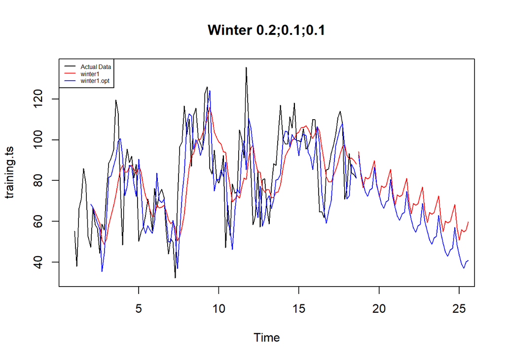

```r
#Plot time series
plot(training.ts,main="Winter 0.2;0.1;0.1",type="l",col="black",
     xlim=c(1,25),pch=12)
lines(xhat1,type="l",col="red")
lines(xhat1.opt,type="l",col="blue")
lines(forecast1,type="l",col="red")
lines(forecast1.opt,type="l",col="blue")
legend("topleft",c("Actual Data",expression(paste(winter1)),
                   expression(paste(winter1.opt))),cex=0.5,
       col=c("black","red","blue"),lty=1)
```

#### Akurasi Data Latih

```r
#Akurasi data training
SSE1<-winter1$SSE
MSE1<-winter1$SSE/length(training.ts)
RMSE1<-sqrt(MSE1)
akurasi1 <- matrix(c(SSE1,MSE1,RMSE1))
row.names(akurasi1)<- c("SSE", "MSE", "RMSE")
colnames(akurasi1) <- c("Akurasi")
akurasi1
```

```
##          Akurasi
## SSE  55238.12081
## MSE    445.46872
## RMSE    21.10613
```

```r
SSE1.opt<-winter1.opt$SSE
MSE1.opt<-winter1.opt$SSE/length(training.ts)
RMSE1.opt<-sqrt(MSE1.opt)
akurasi1.opt <- matrix(c(SSE1.opt,MSE1.opt,RMSE1.opt))
row.names(akurasi1.opt)<- c("SSE1.opt", "MSE1.opt", "RMSE1.opt")
colnames(akurasi1.opt) <- c("Akurasi")
akurasi1.opt
```

```
##               Akurasi
## SSE1.opt  38178.70572
## MSE1.opt    307.89279
## RMSE1.opt    17.54687
```

```r
akurasi1.train = data.frame(Model_Winter = c("Winter 1","Winter1 optimal"),
                            Nilai_SSE=c(SSE1,SSE1.opt),
                            Nilai_MSE=c(MSE1,MSE1.opt),Nilai_RMSE=c(RMSE1,RMSE1.opt))
akurasi1.train
```

```
##      Model_Winter Nilai_SSE Nilai_MSE Nilai_RMSE
## 1        Winter 1  55238.12  445.4687   21.10613
## 2 Winter1 optimal  38178.71  307.8928   17.54687
```

#### Akurasi Data Uji

```r
class(forecast1)
```

```
## [1] "ts"
```

```r
class(forecast1.opt)
```

```
## [1] "ts"
```

```r
length(testing$`PM2.5 (ug/m3)`)
```

```
## [1] 32
```

```r
# Akurasi Data Testing

# Forecast Model 1 berupa data frame, ambil kolom pertama
pred1 <- as.numeric(forecast1[[1]])

# Forecast Model 1 Optimal berupa time series
pred1.opt <- as.numeric(forecast1.opt)

# Data aktual testing
aktual <- as.numeric(testing$`PM2.5 (ug/m3)`)

# Samakan panjang
pred1 <- pred1[1:length(aktual)]
pred1.opt <- pred1.opt[1:length(aktual)]

# Model 1
selisih1 <- pred1 - aktual

SSEtesting1 <- sum(selisih1^2)
MSEtesting1 <- SSEtesting1 / length(aktual)

# Model 1 Optimal
selisih1.opt <- pred1.opt - aktual

SSEtesting1.opt <- sum(selisih1.opt^2)
MSEtesting1.opt <- SSEtesting1.opt / length(aktual)

# Tampilkan hasil
SSEtesting1
```

```
## [1] NA
```

```r
MSEtesting1
```

```
## [1] NA
```

```r
SSEtesting1.opt
```

```
## [1] 29643.03
```

```r
MSEtesting1.opt
```

```
## [1] 926.3447
```

```r
akurasi_testing <- data.frame(
  Model = c("Model1", "Model Optimum"),
  SSE   = c(SSEtesting1, SSEtesting1.opt),
  MSE   = c(MSEtesting1, MSEtesting1.opt)
)

akurasi_testing
```

```
##           Model      SSE      MSE
## 1        Model1       NA       NA
## 2 Model Optimum 29643.03 926.3447
```

### Winter Multiplikatif

Model multiplikatif digunakan cocok digunakan jika plot data asli menunjukkan fluktuasi musiman yang bervariasi.

#### Pemulusan

```r
#Pemulusan dengan winter multiplikatif
winter2 <- HoltWinters(training.ts,alpha=0.2,beta=0.1,gamma=0.3,seasonal = "multiplicative")
winter2$fitted
```

```
## Time Series:
## Start = c(2, 1)
## End = c(18, 5)
## Frequency = 7
##                xhat     level       trend    season
##  2.000000  47.31238  68.44898 -1.53836497 0.7070983
##  2.142857  71.60600  66.94719 -1.53470718 1.0946841
##  2.285714  63.52873  64.50702 -1.62525391 1.0102887
##  2.428571  60.99038  61.88790 -1.72464002 1.0137479
##  2.571429  74.53857  59.28969 -1.81199668 1.2968260
##  2.714286  56.43198  52.85471 -2.27429574 1.1156884
##  2.857143  37.16196  51.02059 -2.23027765 0.7616667
##  3.000000  36.76512  53.69964 -1.73934537 0.7075619
##  3.142857  66.66345  62.61468 -0.67390703 1.0762451
##  3.285714  65.14738  66.01727 -0.26625733 0.9908195
##  3.428571  70.89997  70.94421  0.25306257 0.9958242
##  3.571429  89.15698  76.07179  0.74051475 1.1607121
##  3.714286  93.92846  82.06076  1.26536022 1.1272391
##  3.857143  74.67250  86.73946  1.60669398 0.8452264
##  4.000000  76.76767  88.47885  1.61996384 0.8520386
##  4.142857  97.61378  83.48307  0.95838892 1.1559935
##  4.285714  89.73209  82.48764  0.76300762 1.0778545
##  4.428571  91.37763  84.33714  0.87165698 1.0723966
##  4.571429 106.95314  84.75061  0.82583755 1.2497965
##  4.714286  98.88805  83.18355  0.58654833 1.1804695
##  4.857143  68.67105  80.80932  0.29047039 0.8467475
##  5.000000  66.62666  85.66721  0.74721222 0.7710132
##  5.142857  92.67148  82.18688  0.32445786 1.1231363
##  5.285714  82.57705  75.79342 -0.34733375 1.0945174
##  5.428571  74.58031  70.81048 -0.81089428 1.0654393
##  5.571429  80.65337  67.86488 -1.02436508 1.2066539
##  5.714286  72.32856  65.27019 -1.18139714 1.1285679
##  5.857143  55.35464  62.75683 -1.31459354 0.9009216
##  6.000000  43.55866  61.51891 -1.30692671 0.7234218
##  6.142857  69.08987  69.24075 -0.40404976 1.0036779
##  6.285714  68.47731  68.35051 -0.45266840 1.0085343
##  6.428571  70.15220  68.78977 -0.36347577 1.0252229
##  6.571429  81.18785  69.53620 -0.25248531 1.1718172
##  6.714286  74.04573  67.73265 -0.40759223 1.0998244
##  6.857143  56.93260  63.85406 -0.75469190 0.9022689
```

[output cut: 67 more lines]

```
## 16.571429  87.26183  89.10889 -0.92761560 0.9895732
## 16.714286  89.36333  83.04198 -1.44154477 1.0951330
## 16.857143  86.09667  80.85914 -1.51567512 1.0851136
## 17.000000  76.99077  79.28725 -1.52129612 0.9900318
## 17.142857  72.34320  81.05727 -1.19216470 0.9058174
## 17.285714  76.42419  85.37544 -0.64113090 0.9019273
## 17.428571  84.14997  90.53780 -0.06078230 0.9300701
## 17.571429  88.63241  96.23644  0.51515988 0.9160821
## 17.714286 111.97894 102.31717  1.07171686 1.0830849
## 17.857143 112.36241 102.64029  0.99685767 1.0841905
## 18.000000  99.89877  95.98476  0.23161924 1.0382719
## 18.142857  89.34098  91.75488 -0.21453108 0.9759738
## 18.285714  89.57192  92.35165 -0.13340144 0.9713037
## 18.428571  90.52292  91.05720 -0.24950564 0.9968640
## 18.571429  86.73298  89.27916 -0.40235939 0.9758787
```

```r
xhat2 <- winter2$fitted[,2]

winter2.opt<- HoltWinters(training.ts, alpha= NULL,  beta = NULL, gamma = NULL, seasonal = "multiplicative")
winter2.opt$fitted
```

```
## Time Series:
## Start = c(2, 1)
## End = c(18, 5)
## Frequency = 7
##                xhat     level     trend    season
##  2.000000  47.31238  68.44898 -1.538365 0.7070983
##  2.142857  71.67151  67.01055 -1.538222 1.0946841
##  2.285714  62.05599  62.96582 -1.541806 1.0102887
##  2.428571  58.75754  59.50525 -1.544550 1.0137479
##  2.571429  71.62541  56.77756 -1.546241 1.2968260
##  2.714286  47.15556  43.82843 -1.562546 1.1156884
##  2.857143  35.38501  48.01167 -1.554330 0.7616667
##  3.000000  42.16852  61.14474 -1.533329 0.7073901
##  3.142857  89.91797  84.55324 -1.497666 1.0826242
##  3.285714  80.99472  82.39037 -1.498617 1.0012729
##  3.428571  85.46271  86.28362 -1.490908 1.0079017
##  3.571429 106.59250  90.05576 -1.483383 1.2034508
##  3.714286 107.20816  94.48588 -1.474927 1.1526402
##  3.857143  76.65253  95.83563 -1.470888 0.8123006
##  4.000000  70.34524  93.41005 -1.472253 0.7651395
##  4.142857  80.90987  76.39679 -1.494475 1.0802052
##  4.285714  77.56438  77.63940 -1.490561 1.0185891
##  4.428571  86.38180  85.81721 -1.476737 1.0242034
##  4.571429 103.11046  85.69503 -1.474800 1.2242956
##  4.714286  90.38323  79.26153 -1.481890 1.1620423
##  4.857143  58.37976  73.56143 -1.487922 0.8100030
##  5.000000  65.41974  92.06043 -1.459343 0.7220635
##  5.142857  84.75715  79.18147 -1.475672 1.0907442
##  5.285714  64.35968  62.77163 -1.497025 1.0503482
##  5.428571  57.65975  57.55430 -1.502345 1.0286839
##  5.571429  69.17947  58.99923 -1.498130 1.2030982
##  5.714286  65.08518  58.40932 -1.496832 1.1436010
##  5.857143  47.47182  56.78220 -1.497018 0.8586717
##  6.000000  40.92330  60.52117 -1.489531 0.6932435
##  6.142857  87.01647  86.84989 -1.449756 1.0189267
##  6.285714  75.31711  74.47831 -1.465372 1.0315583
##  6.428571  73.32166  71.77233 -1.467146 1.0429054
##  6.571429  84.77293  71.62552 -1.465258 1.2082755
##  6.714286  71.95057  64.42923 -1.473453 1.1428748
##  6.857143  46.90400  54.83168 -1.485069 0.8792310
```

[output cut: 67 more lines]

```
## 16.571429  72.27167  70.96134 -1.328652 1.0378987
## 16.714286  73.33988  64.13728 -1.336510 1.1678182
## 16.857143  74.81289  68.39880 -1.328505 1.1154400
## 17.000000  68.52497  72.44842 -1.320815 0.9634090
## 17.142857  75.33469  85.16973 -1.300737 0.8982424
## 17.285714  89.04034  97.23082 -1.281632 0.9279946
## 17.428571 100.86612 103.93081 -1.270220 0.9825203
## 17.571429 108.41881 108.25931 -1.262214 1.0132874
## 17.714286 129.95607 110.07416 -1.257815 1.1942698
## 17.857143 110.94900  98.73646 -1.272227 1.1383560
## 18.000000  77.49771  78.23061 -1.299728 1.0073680
## 18.142857  70.13381  76.51853 -1.300318 0.9324046
## 18.285714  82.93796  88.79423 -1.280906 0.9477181
## 18.428571  86.51045  88.08719 -1.280086 0.9965826
## 18.571429  85.31199  84.82984 -1.282913 1.0211266
```

```r
xhat2.opt <- winter2.opt$fitted[,2]
```

#### Peramalan

```r
#Forecast
forecast2 <- predict(winter2, n.ahead = 32)
forecast2.opt <- predict(winter2.opt, n.ahead = 32)
```

#### Plot Deret Waktu

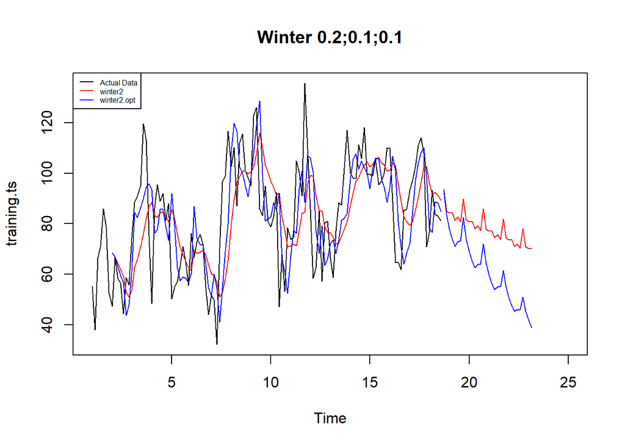

```r
#Plot time series
plot(training.ts,main="Winter 0.2;0.1;0.1",type="l",col="black",
     xlim=c(1,25),pch=12)
lines(xhat2,type="l",col="red")
lines(xhat2.opt,type="l",col="blue")
lines(forecast2,type="l",col="red")
lines(forecast2.opt,type="l",col="blue")
legend("topleft",c("Actual Data",expression(paste(winter2)),
                   expression(paste(winter2.opt))),cex=0.5,
       col=c("black","red","blue"),lty=1)
```

#### Akurasi Data Latih

```r
#Akurasi data training
SSE2<-winter2$SSE
MSE2<-winter2$SSE/length(training.ts)
RMSE2<-sqrt(MSE2)
akurasi1 <- matrix(c(SSE2,MSE2,RMSE2))
row.names(akurasi1)<- c("SSE2", "MSE2", "RMSE2")
colnames(akurasi1) <- c("Akurasi lamda=0.2")
akurasi1
```

```
##       Akurasi lamda=0.2
## SSE2        56626.71709
## MSE2          456.66707
## RMSE2          21.36977
```

```r
SSE2.opt<-winter2.opt$SSE
MSE2.opt<-winter2.opt$SSE/length(training.ts)
RMSE2.opt<-sqrt(MSE2.opt)
akurasi1.opt <- matrix(c(SSE2.opt,MSE2.opt,RMSE2.opt))
row.names(akurasi1.opt)<- c("SSE2.opt", "MSE2.opt", "RMSE2.opt")
colnames(akurasi1.opt) <- c("Akurasi")
akurasi1.opt
```

```
##               Akurasi
## SSE2.opt  40578.09557
## MSE2.opt    327.24271
## RMSE2.opt    18.08985
```

```r
akurasi2.train = data.frame(Model_Winter = c("Winter 1","winter2 optimal"),
                            Nilai_SSE=c(SSE2,SSE2.opt),
                            Nilai_MSE=c(MSE2,MSE2.opt),Nilai_RMSE=c(RMSE2,RMSE2.opt))
akurasi2.train
```

```
##      Model_Winter Nilai_SSE Nilai_MSE Nilai_RMSE
## 1        Winter 1  56626.72  456.6671   21.36977
## 2 winter2 optimal  40578.10  327.2427   18.08985
```

#### Akurasi Data Uji

```r
# Akurasi Data Testing
forecast2 <- data.frame(forecast2)
testing.ts <- data.frame(testing.ts)

selisih2 <- forecast2 - testing.ts
SSEtesting2 <- sum(selisih2^2)
MSEtesting2 <- SSEtesting2 / nrow(testing.ts)

forecast2.opt <- data.frame(forecast2.opt)
selisih2.opt <- forecast2.opt - testing.ts
SSEtesting2.opt <- sum(selisih2.opt^2)
MSEtesting2.opt <- SSEtesting2.opt / nrow(testing.ts)
```

```r
# Atau Rapikan dalam tabel
akurasi_testing2 <- data.frame(
  Model = c("Model2", "Model2 Optimal"),
  SSE = c(SSEtesting2, SSEtesting2.opt),
  MSE = c(MSEtesting2, MSEtesting2.opt)
)

akurasi_testing2
```

```
##            Model      SSE       MSE
## 1         Model2 16458.38  514.3243
## 2 Model2 Optimal 43739.80 1366.8689
```

#Kesimpulan

Berdasarkan hasil perbandingan akurasi pada data uji, metode SES merupakan metode terbaik karena menghasilkan nilai kesalahan peramalan paling kecil dibandingkan metode lainnya.